# Mapping the Conceptual Foundation(s) of “Data Science Education”

Author

Michelle Hoda Wilkerson

Abstract

The emerging field of data science education is broadly interdisciplinary, and related literature is distributed across a variety of outlets. Navigating this landscape can be challenging, especially for those who are just entering the field or who seek insights from multiple fields. This report contributes to a growing body of research that aims to characterize the emerging field of “Data Science Education.” It presents a reference co-citation analysis drawing from 7,000+ works that are cited by papers that explicitly identify themselves in their title, keywords, or abstract as concerned with “data science education”—thus representing the de facto foundations of this field. The structure of the resulting reference co-citation network suggests that while there are some “broker” references that are broadly cited across the emerging data science education literature, the field is building upon three distinctive, conceptually coherent, and rather isolated clusters of reference works. These clusters generally focus on Undergraduate Data Science programs, K-12 Data Science, and Computational Approaches to Data for Non-Majors, respectively. I characterize each cluster with attention to the audiences, themes, pedagogies, and methodologies emphasized, and explore the nature of recent data science education papers that draw heavily from each cluster. All three clusters demonstrate attention to student-centered pedagogies, research methodologies that highlight student experience, and ethics and diversity. However, they also highlight important differences in scholarly foundations between undergraduate and K-12 data science education efforts, between data science education efforts for majors versus non-majors, and between K-12 data science initiatives emerging from different groups and disciplines.

**Note**

This is a Quarto-generated html version of Wilkerson, M. H. (2025). Mapping the Conceptual Foundation(s) of Data Science Education. Just Accepted in *Harvard Data Science Review*. https://doi.org/10.1162/99608f92.9ac68105

Data science sits at the intersection of many disciplines, ranging from statistics and computer science to a variety of application domains. It is not surprising, then, that there is also wide diversity in who is involved in data science *education*, and in how this emerging field is conceptualized (*Data Science Education*, n.d.). Navigating the landscape of data science education research can be challenging, especially for those who are just entering the field or who seek complementary insights from the various scholarly communities that are involved. Different academic communities may use different terminology, or they may hold different conceptualizations for the same key terms, “talking past” one another. Publication practices and norms also differ across fields, making it harder for researchers to find relevant work. Meanwhile, there are still only a few venues (including the *Harvard Data Science Review*, *Journal of Statistics and Data Science Education*, and *Teaching Statistics*) that specifically advertise data science education as an area of focus (Hazzan & Mike, 2021).

There is growing evidence that it is time to take stock and build common understandings of data science education as a field in its own right, despite (or perhaps because of) the difficulty in navigating this interdisciplinary scholarly landscape. This report seeks to clarify the scholarly communities that are shaping this emerging field by presenting a mixed-methods investigation of 287 papers that explicitly identify themselves in their title, keywords, or abstract as concerned with “data science education,” as well as of the 7,000+ reference works that, together, form the *de facto* foundations of data science education scholarship. These reference works are extracted from the focal set of “data science education” papers to construct a co-citation network that highlights the structure of the knowledge base(s) that are informing data science education as an emerging field.

Analysis of the reference co-citation network suggests that while there are several shared (but not- so-shared) “broker” references that are broadly cited within the emerging data science education literature, current data science education scholarship is built atop three distinctive and conceptually coherent, but rather isolated clusters of reference work. I characterize each cluster with attention to the audiences, themes, pedagogy, and methodologies emphasized, and explore the nature of recent data science education papers that draw from each cluster. I then examine areas of agreement and divergence across the clusters. All three clusters of literature include attention to student-centered pedagogies, case-based methodologies that highlight student experience, and ethics and diversity. However, there are notable areas of divergence, especially between undergraduate and K-12 data science education efforts, between data science majors versus non- majors, and between K-12 data science initiatives emerging from different groups.

My goal is to raise awareness of the diversity of communities working on data science education, and to encourage deeper engagement with literature and researchers across these communities. In that spirit, this interactive open-source Quarto document allows readers to follow along with my methods in real time and to peruse the full lists of reference works that make up the many worlds of data science education. Understanding what we can learn from each other can support stronger, more coherent trajectories for future data science students, as well as for all students who will find themselves navigating a data-filled world.

# 1. Why Map Data Science Education Scholarship?

As data science education emerges as a discipline in its own right (Finzer, 2013; Lee et al., 2021; Mike et al., 2023; National Academies of Sciences, Engineering, and Medicine, 2018, 2023), still little is known about its core scholarly foundations. This is not surprising, given the rapid evolution of the field of data science and the variety of academic communities that are involved in its development. In many ways, data science education is even more interdisciplinary than data science as a field. Studying the teaching and learning of data science not only involves the content that is being taught, but also requires attention to theories of learning, educational infrastructures, appropriate social science methodologies, and curricular frameworks. There are also multiple established literatures that address some important conceptual foundations of data science (e.g. statistics education, Ben-Zvi et al., 2018; Fincher & Robins, 2019; Nolan & Temple Lang, 2010 and computing education) and of related topics (e.g. scientific visualization, Edelson & Gordin, 1998; data literacies, Pangrazio & Selwyn, 2019).

Despite these complexities, data science education research and curriculum development races ahead not only at universities but also in K-12 (National Academies of Sciences, Engineering, and Medicine, 2023; Weiland & Engledowl, 2022), at community colleges (Baumer & Horton, 2023), and in the professional development of teachers (Hudson et al., 2024). It is important to understand how different research communities are approaching data science education, what these communities might learn from each other and from their histories of scholarship, and what this all might mean for the different types of “data science education” students might experience across levels and institutions.

## 1.1 Data Science Education as an Interdisciplinary Field

The earliest programs in data science were born within a variety of departments including statistics, computer science, business analytics, information and library sciences, each with distinctive emphases and approaches. One of the clearest differences in approach to data science education approaches has been between statistics and computer science. A recent scoping review of data science education literature by Msweli and colleagues (2023) found that most papers they identified in their search did not explicitly name data science, but rather computer science or statistics, as the home discipline of their work. A pair of workshops offered in 2019 at the ACM’s Special Interest Group in Computer Science Education (Cetinkaya-Rundel, Posner, et al., 2019) (Cetinkaya-Rundel, Danyluk, et al., 2019) and at the Joint Statistical Meetings (Cetinkaya-Rundel, Posner, et al., 2019), respectively, highlight efforts by both communities to foster collaboration between disciplines.

These distinctive approaches to data science education can also be detected in published products themselves. In a recent review, Mike and colleagues (2023) leveraged k-means clustering techniques to classify a collection of over 1,000 papers selected on the intersection of the phrase “data science” with education-related terms such as “education”, “teaching”, and “curriculum” to identify core areas of focus for this emerging field. They identified five key themes: curriculum; pedagogy; STEM skills; domain adaptation; and social aspects. While the themes were not traced to disciplinary communities of origin, there is some suggestion of domain specialization within the emergent themes suggested by the cluster analysis. For example, within a cluster called “STEM skills”, two clusters (3.1 – Statistics education and 3.5 – Statistics for data science) were identified as connected to statistics, and three (3.2 – Computer science for data science; 3.3 – Cloud computing in data science education; and 3.4 – Data engineering) were identified as connected to computer science.

Another consistently emphasized feature of data science as a field is its deep integration with a variety of application domains. These domain-specific programs of study were also represented in Mike et al’s (2023) study as a cluster called “Domain adaptation,” which represented fields as diverse as health (4.2, 4.7), business analytics (4.1), and bioinformatics (4.4). Given the specialized needs and methods of different application areas, it is reasonable to assume that smaller communities of research may emerge around particular application domains or related frameworks and methods.

More signs of scholarly specialization emerge even within narrower focal areas of data science education research. Rosenberg and Jones (2024) present vignettes illustrating substantially different visions of what constitutes “data science education” at the K-12 level. The vignettes were derived from an analysis of three recent journal special issues (a total of 28 papers and their shared references) dedicated to the topic. They found that despite their shared topical focus, each special issue reflected distinct orientations toward the field, emphasizing the material, personal, or disciplinary aspects of data science. Rosenberg and Jones highlighted the different levels of cohesiveness in what literature was cited by papers within versus across special issues, as well as a relative lack of cohesiveness in what literature was cited by scholars focused on K-12 versus undergraduate education.

All this suggests that there may be relatively independently developing communities of data science education scholarship. These communities are likely attending to different themes, audiences, and approaches of the sort identified in Mike et al (2023); and, they are likely drawing from somewhat different foundational literatures as highlighted by Rosenberg & Jones (2024). However, these prior reviews varied dramatically in scope and method, making it difficult to understand the relationship between thematic trends and different foundational literatures. One goal of this paper is to offer a “meso” level examination that works to map broad emerging themes in the data science education literature to their respective intellectual foundations.

## 1.2 Document Co-Citation Mapping to Understand Interdisciplinary Fields

Science mapping is a form of bibliometric analysis that leverages metadata from published works to characterize the structure of scholarly literatures. It is especially useful for understanding fields that are developing rapidly and that are “voluminous and fragmented” (Aria & Cuccurullo, 2017). Here I rely on co-citation analysis, one of the most popular and validated bibliometric methods (Zupic & Čater, 2015). Co-citation analysis measures how often certain entities (such as authors, institutions, journals, or documents) appear together in the reference lists of a focal set of papers, assessing entities that appear together more frequently as more conceptually proximal.

Document co-citation analysis in focuses on the individual works that appear together in reference lists. This method is especially useful for mapping the literature base of rapidly-developing fields that may be drawing from diverse academic disciplines and therefore are at risk of developing into isolated subareas (Trujillo & Long, 2018). The focal documents for this co-citation analysis are papers that appear in the reference lists of published works that identify the specific phrase “data science education” as a central focus through inclusion in their titles, abstracts, or keywords. The collection of references listed by these works can be understood as the “knowledge base” that informs data science education, and their co-citation frequency and other structural entailments of co-citation patterns can be understood as characterizing the “intellectual structure” of the field (Zupic & Čater, 2015, pp. 11–12).

To better understand the topics that underlie this “intellectual structure,” I employ both qualitative content analysis and bibliographic coupling methods. Qualitative content analysis involves examining the content of papers that comprise each cluster to determine what are their primary student audiences, conceptual themes, teaching strategies, and methodologies. While automated computational topic extraction methods are sometimes used for this purpose, Held (2022) cautions that these are derived from generic clustering algorithms and may not be sufficient for bibliometric analyses. Instead, I manually analyzed paper abstracts and, when required, full texts to determine the specific topics of focus within the data science education scholarship.

Bibliographic coupling allows deeper exploration of what are the products of different knowledge bases, by identifying papers that draw heavily from specific clusters of foundational literature. Following the recommendation in Zupic and Čater (2015), I limit bibliographic coupling analysis to only the most recent 5 years of publications. For each cluster, I identify specific papers within the focal set of papers that reference “data science education” as “building on” a specific cluster if they have more than 5 reference works that are included in the bibliographic co-citation analysis, and at least 80% of those references belong to that cluster.

The primary goal of this work is to identify complementary communities of scholars and their area(s) of focus, rather than to make evaluative claims about the impact of certain authors or papers. Additionally, given that different disciplines have different publication norms, over-reliance on quantities such as publication count or citation frequency is especially inappropriate. Therefore, the computational analysis and reporting of findings focus on the structural and conceptual features of co-citation, rather than on assessing the impact of specific authors, communities, or institutions. As Haustein and Larivière (2015) emphasize, it is important to recognize bibliometric signals as indicators, not direct measures of impact or significance.

# 2. Constructing the Bibliographic Datasets

This analysis makes extensive use of the R `bibliometrix` package (Aria & Cuccurullo, 2017) for constructing, analyzing, and visualizing bibliographic records. I use the `dplyr` package for data handling (Wickham et al., 2023), and the `stringr` and `textTools` packages to process and compare scholarly reference records. The `DT` package (*DT*, 2024) is used to generate interactive data displays. All data and code used to generate this document are available for review at [GitHub](https://calcord.github.io/dse-citan/dse_citan.html).

```r
# for the analysis
library(bibliometrix)

# for working with data
library(dplyr)
library(stringr)
library(textTools)

# for a pretty document
library(DT)
```

Consistent with the bibliometric co-citation methods described in Section 1.2, this analysis focuses on three interrelated datasets (also illustrated in Figure 1).

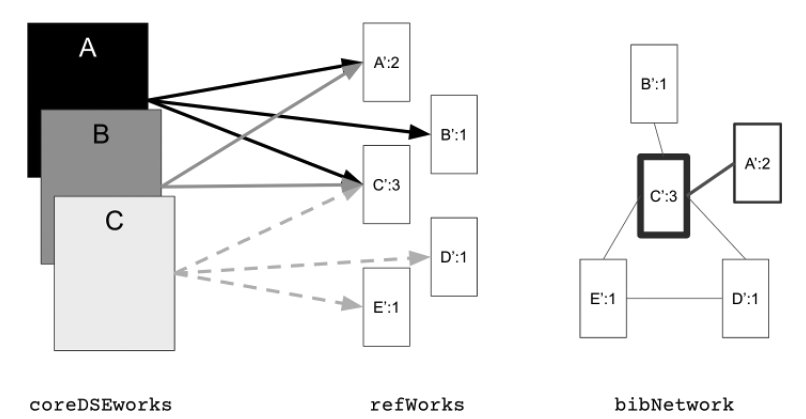

Bibliographic Datasets. Three key datasets: coreDSEworks describes a collection of papers centrally focused on “data science education,” refWorks includes all papers that appear in the reference lists of coreDSEworks, and bibNetwork describes co-citation patterns between refWorks as a weighted network.

## 2.1 Identifying “Core” Data Science Education Publications

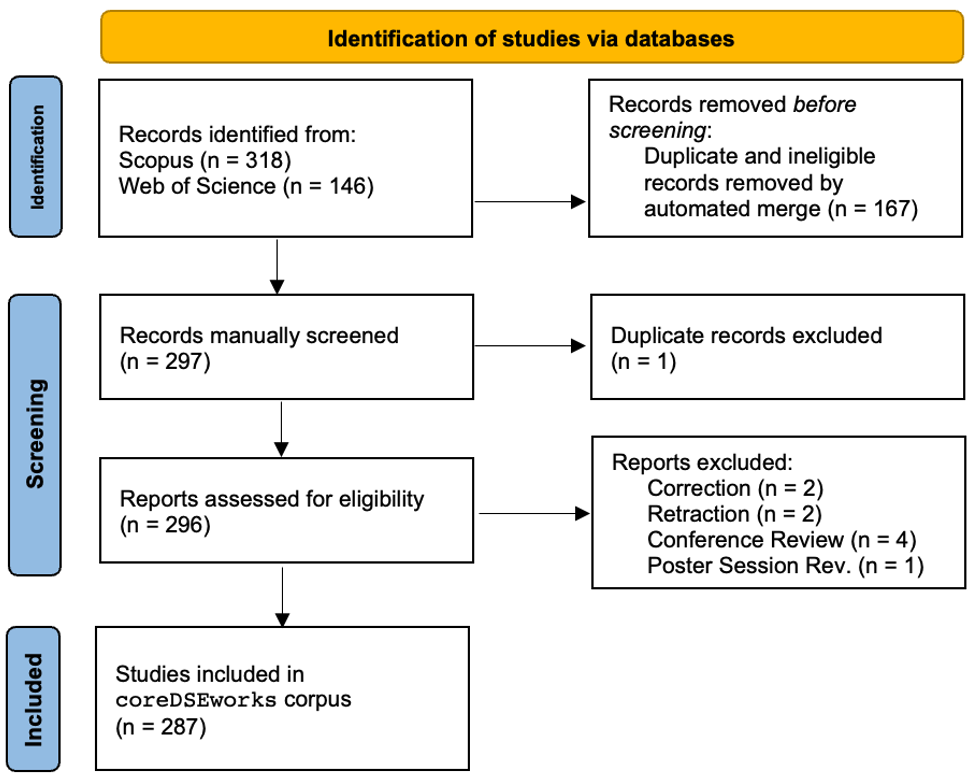

PRISMA diagram describing construction of the coreDSEworks corpus

```r
source("scripts/read_works.R")
coreDSEworks <- getCoreDSEWorks()
```

While the focus of this paper is not on the core works themselves, it is useful to briefly review some key descriptive characteristics of the `coreDSEworks` collection to determine its validity for this analysis. The histogram featured in Figure 3 reflects the nascent nature of this area of study, with the first publication appearing in 2012 and relatively steady growth since then.

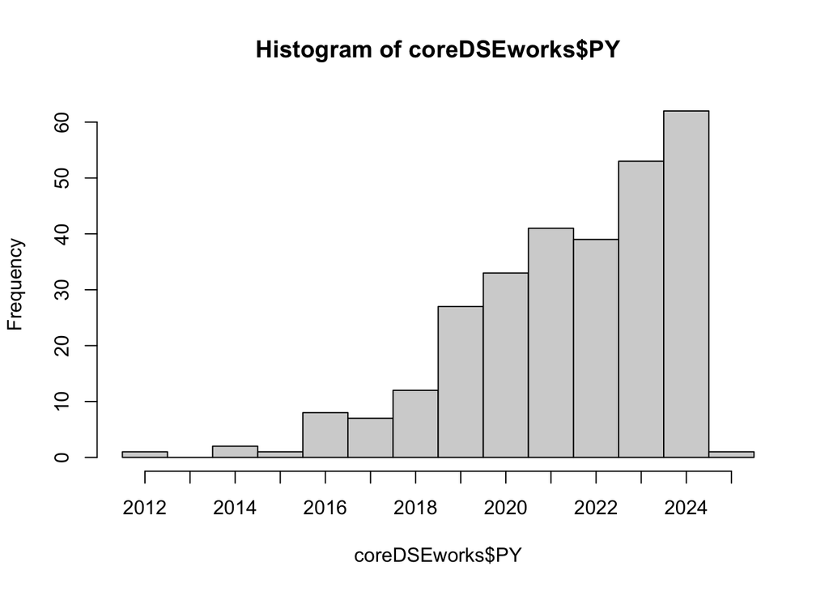

```r
# use breaks to make sure empty bins (2013) still show
hist(coreDSEworks$PY, breaks=seq(2011,2025,1), xaxt='n')

# shuffle the axis to place each year in center of the corresponding bar
axis(side=1, at=seq(2011.5,2024.5, 1), labels=seq(2012,2025,1))
```

```r
datatable(coreDSEworks[
  sample(1:nrow(coreDSEworks)),
  c(1,5,4,6)],
  colnames=c('Author','Year','Title', 'Source'),
  rownames=FALSE,
  options=list(pageLength=5, class='compact stripe')
)
```

| Author | Year | Title | Source |
| --- | --- | --- | --- |
| KHALEMSKY A, GELBARD R, STUKALIN Y | 2024 | CONSTRUCTING A COURSE ON CLASSIFICATION METHODS FOR UNDERGRADUATE NON-STEM STUDENTS: STRIVING TO REACH KNOWLEDGE DISCOVERY | JOURNAL OF STATISTICS AND DATA SCIENCE EDUCATION |
| ROHANI N, GAL K, GALLAGHER M, MANATAKI A | 2024 | PROVIDING INSIGHTS INTO HEALTH DATA SCIENCE EDUCATION THROUGH ARTIFICIAL INTELLIGENCE | BMC MEDICAL EDUCATION |
| LIU Y, WEI X | 2020 | HOW TO USE STOCK DATA FOR DATA SCIENCE EDUCATION: A SIMULATED TRADING PLATFORM IN CLASSROOM | PROCEEDINGS OF 2ND INTERNATIONAL CONFERENCE ON COMPUTER SCIENCE AND EDUCATIONAL INFORMATIZATION, CSEI 2020 |
| JENG W, TSAI F, LEE J | 2020 | IDENTIFYING DATA-FOCUSED CURRICULUM IN WORLDWIDE ISCHOOLS: PRELIMINARY DATA ACQUISITION FOR ASIA-PACIFIC AND EUROPEAN MEMBERS | PROCEEDINGS OF THE ASSOCIATION FOR INFORMATION SCIENCE AND TECHNOLOGY |
| FARAHI A, STROUD J | 2018 | THE MICHIGAN DATA SCIENCE TEAM: A DATA SCIENCE EDUCATION PROGRAM WITH SIGNIFICANT SOCIAL IMPACT | 2018 IEEE DATA SCIENCE WORKSHOP (DSW) |
| HAGEN L, ANDREWS J, FEDERER L, BENOIT G | 2019 | DATA SCIENCE EDUCATION IN LIBRARY AND INFORMATION SCIENCE SCHOOLS | PROCEEDINGS OF THE ASSOCIATION FOR INFORMATION SCIENCE AND TECHNOLOGY |
| BORNSCHLEGL M, BERWIND K, KAUFMANN M, ENGEL F, WALSH P, HEMMJE M, RIESTRA R | 2016 | IVIS4BIGDATA: A REFERENCE MODEL FOR ADVANCED VISUAL INTERFACES SUPPORTING BIG DATA ANALYSIS IN VIRTUAL RESEARCH ENVIRONMENTS | LECTURE NOTES IN COMPUTER SCIENCE (INCLUDING SUBSERIES LECTURE NOTES IN ARTIFICIAL INTELLIGENCE AND LECTURE NOTES IN BIOINFORMATICS) |
| ROSSI R | 2021 | DATA SCIENCE EDUCATION BASED ON ADDIE MODEL AND THE EDISON FRAMEWORK | 2021 INTERNATIONAL CONFERENCE ON BIG DATA ENGINEERING AND EDUCATION (BDEE 2021) |
| CHEN L, THAI J | 2024 | ASSESSMENT-VIA-TEACHING: EXPLORING AN ALTERNATIVE ASSESSMENT STRATEGY IN UNDERGRADUATE INTRODUCTORY DATA SCIENCE COURSE | SIGCSE 2024 - PROCEEDINGS OF THE 55TH ACM TECHNICAL SYMPOSIUM ON COMPUTER SCIENCE EDUCATION |
| BROOKS C, QUINTANA R, CHOI H, QUINTANA C, NECAMP T, GARDNER J | 2021 | TOWARDS CULTURALLY RELEVANT PERSONALIZATION AT SCALE: EXPERIMENTS WITH DATA SCIENCE LEARNERS | INTERNATIONAL JOURNAL OF ARTIFICIAL INTELLIGENCE IN EDUCATION |

[output cut: 277 more lines]

Of the publication records that are included in the `coreDSEworks` dataset, seven do not include information about cited references. Manual inspection reveals that these records are editorials and commentaries. Nevertheless, these works represent substantive contributions to the literature, and provide information about the venues and authors that are actively contributing to the “data science education” discourse. Therefore, they were not excluded from this dataset. However, because they works do not include reference lists, only 280 records directly impact the construction of the reference works dataset and the reference co-citation network that are described in the following sections and that are the focus of this paper.

## 2.2 Extracting and Cleaning DSE Reference Works

Next, we can construct a new dataset called `refWorks` to represent the full set of works cited by the “data science education” papers included `coreDSEworks`. Extracting each cited paper from the full cited references list of each `coreDSEworks` paper yields a total of 8,694 unique records.

```r
refWorks <- as.data.frame(
  citations(coreDSEworks, field = "article", sep = ";")$Cited)
```

However, as noted by Mike et al (2023), processing reference data is not trivial. The cited reference lists included in Scopus and WoS databases are text-only, and the formats that are used across the style guides of various disciplines engaged in data science education (e.g. Association for Computing Machinery, American Psychological Association, Institute of Electrical and Electronics Engineers) are quite different. Even more standardized ways of citing references, such as the Document Object Identifier number (DOI), are not always included in reference lists or available for all relevant publications.

These difficulties are most likely to arise for higher-profile papers that have been picked up by different scholarly communities, and are therefore cited in multiple formats. Consider, for example, the National Academies’ (2018) report *Data Science for Undergraduates: Opportunities and Options* report. Table 2 features several records which match the substring “data science for undergraduates.” The majority of matching records were intended to represent that report, but have been extracted and tallied as distinct references. Other records that employ abbreviations (e.g., “data sci und opp opt”) but clearly refer to this report also appear as distinct references. The top row, with 18 citations, appears as the most frequently cited record in the whole coreDSEworks dataset, but this reference is clearly severely undercounted.

```r
showabit <- refWorks %>% filter( CR %like% "DATA SCIENCE FOR UNDERGRADUATES" ) %>% head(20)
datatable(showabit,
  rownames=FALSE,
  colnames=c('Cited Reference','Freq'),
  options=list(pageLength=12, class='compact stripe')
)
```

| Cited Reference | Freq |
| --- | --- |
| DATA SCIENCE FOR UNDERGRADUATES: OPPORTUNITIES AND OPTIONS, (2018) | 18 |
| NATIONAL ACADEMIES OF SCIENCES ENGINEERING AND MEDICINE, 2018, DATA SCIENCE FOR UNDERGRADUATES: OPPORTUNITIES AND OPTIONS, DOI DOI 10.17226/25104 | 6 |
| ACADEMIES N., DATA SCIENCE FOR UNDERGRADUATES: OPPORTUNITIES AND OPTIONS, (2018) | 1 |
| ADHIKARI A., DENERO J., JORDAN M. I., INTERLEAVING COMPUTATIONAL AND INFERENTIAL THINKING: DATA SCIENCE FOR UNDERGRADUATES AT BERKELEY, HARVARD DATA SCIENCE REVIEW, (2021) | 1 |
| COMMITTEE ON ENVISIONING THE DATA SCIENCE DISCIPLINE: THE UNDERGRADUATE PERSPECTIVE COMPUTER SCIENCE AND TELECOMMUNICATIONS BOARD BOARD ON MATHEMATICAL SCIENCES AND ANALYTICS COMMITTEE ON APPLIED AND … | 1 |
| DATA SCIENCE FOR UNDERGRADUATES: OPPORTUNITIES AND OP-TIONS, (2018) | 1 |
| DATA SCIENCE FOR UNDERGRADUATES: OPPORTUNITIES AND OPTIONS, A CONSENSUS STUDY REPORT OF THE NATIONAL ACADEMIES OF SCIENCES, ENGINEERING, AND MEDICINE, (2018) | 1 |
| DATA SCIENCE FOR UNDERGRADUATES: OPPORTUNITIES AND OPTIONS, THE NATIONAL ACADEMIES OF SCIENCES ENGINEERING MEDICINE, (2018) | 1 |
| DATA SCIENCE FOR UNDERGRADUATES: OPPORTUNITIES AND OPTIONS., (2018) | 1 |
| MEDICINE NATIONAL ACADEMIES OF SCIENCES, DATA SCIENCE FOR UNDERGRADUATES: OPPORTUNITIES AND OPTIONS, (2018) | 1 |

[output cut: 2 more lines]

If records such as the ones above are not consolidated, the well-known *Data Science for Undergraduates* report (2018) would be represented in the network as several isolated papers, each with only marginal impact on the field as a whole. To address this problem of duplicate records and ensure that the resulting reference co-citation network is accurate, I turn `refWorks` into a lookup table. Using a combination of methods including removal of special characters, automated text matching, and a manual dictionary of duplicate records screened by author and year, each text reference is mapped to a single parent format.

```r
source("scripts/clean_refs.R")
charExcludeList <- '[\r\n\\:\\(\\)+\\?\\|\\"\\“\\”\\,\'\\`\\‘\\.\\*\\’]'
refWorks$CR <- gsub(charExcludeList,'',refWorks$CR) # the original cited works

refWorks$correctedCR <- ""
refWorks$freqAgg <- refWorks$Freq

refWorks <- cleanSpecialChars(refWorks)
refWorks <- cleanManualDuplicates(refWorks)
refWorks <- autoMatch(refWorks,.75)
```

After consolidating duplicate records in this way, the total count of unique reference records falls to 7,484.

The lookup table is then used to replace all duplicate versions of a given reference that appear in the text reference lists within the `coreDSEworks` dataset with the corrected parent reference text. The total citation frequency for each reference is then recalculated by counting the number of `coreDSEworks` that include each corrected parent reference.

```r
 # Replace refs lists in the core works datatable with cleaned refs
 coreDSEworks <- rewriteCleanRefs(coreDSEworks,charExcludeList)

 # update frequencies given found matches in coreDSEworks
 refWorks <- correctFrequenciesCited(refWorks,coreDSEworks)
```

After this round of cleaning, the citation frequency of more popular reference works changes substantially. Table 3 features the top 5 records in the corrected `refWorks` dataset, ordered by frequency of citations. The *Data Science for Undergraduates* reference that was originally listed as the most frequently referenced citation at 18 shows a total of 40 references after consolidation; this reference is superseded by De Veaux et al’s (2017) curriculum guidelines as the reference work that is most cited by the focal `coreDSEworks`.

```r
datatable(refWorks[c(3,5)] %>%
            arrange(desc(refWorks$freqCit)) %>%
            head(100),
  colnames=c('Cited Reference','# Citing DSE Works'),
  rownames=FALSE,
  options=list(pageLength=5, class='compact stripe')
)
```

| Cited Reference | # Citing DSE Works |
| --- | --- |
| DE VEAUX RD AGARWAL M AVERETT M BAUMER BS BRAY A BRESSOUD TC BRYANT L CHENG LZ FRANCIS A GOULD R KIM AY KRETCHMAR M LU Q MOSKOL A NOLAN D PELAYO R RALEIGH S SETHI RJ SONDJAJA M TIRUVILUAMALA N ET AL C… | 45 |
| DATA SCIENCE FOR UNDERGRADUATES OPPORTUNITIES AND OPTIONS 2018 | 40 |
| ANDERSON P BOWRING J MCCAULEY R POTHERING G STARR C AN UNDERGRADUATE DEGREE IN DATA SCIENCE CURRICULUM AND A DECADE OF IMPLEMENTATION EXPERIENCE PROCEEDINGS OF THE 45TH ACM TECHNICAL SYMPOSIUM ON COMP… | 26 |
| LEE VR WILKERSON MH LANOUETTE K A CALL FOR A HUMANISTIC STANCE TOWARD K–12 DATA SCIENCE EDUCATION EDUCATIONAL RESEARCHER 50 9 PP 664-672 2021 | 25 |
| HARDIN J HOERL R HORTON NJ NOLAN D BAUMER B HALL-HOLT O MURRELL P PENG R ROBACK P TEMPLE LANG D WARD MD DATA SCIENCE IN STATISTICS CURRICULA PREPARING STUDENTS TO THINK WITH DATA THE AMERICAN STATISTI… | 23 |
| DONOHO D 50 YEARS OF DATA SCIENCE JOURNAL OF COMPUTATIONAL AND GRAPHICAL STATISTICS 26 4 PP 745-766 2017 | 22 |
| BARGAGLIOTTI A FRANKLIN C ARNOLD P GOULD R JOHNSON S PEREZ L SPANGLER DA PRE-K-12 GUIDELINES FOR ASSESSMENT AND INSTRUCTION IN STATISTICS EDUCATION II GAISE II 2020 | 21 |
| LEE VR WILKERSON M DATA USE BY MIDDLE AND SECONDARY STUDENTS IN THE DIGITAL AGE A STATUS REPORT AND FUTURE PROSPECTS 2018 | 21 |
| FINZER W THE DATA SCIENCE EDUCATION DILEMMA TECHNOLOGY INNOVATIONS IN STATISTICS EDUCATION 7 2 2013 | 20 |
| ENGEL J STATISTICAL LITERACY FOR ACTIVE CITIZENSHIP A CALL FOR DATA SCIENCE EDUCATION STATISTICS EDUCATION RESEARCH JOURNAL 16 1 PP 44-49 2017 | 18 |

[output cut: 90 more lines]

## 2.3 Indexing Between Core and Reference Works

To facilitate interpretation of the results, I created unique document indices to link reference records across datasets. The indices leverage a naming convention that is also employed by the bibliometrix analysis package when it generates a co-citation network from bibliographic data (see Section 3.2). Each reference document is assigned a name in the format: author last name, author first initial(s), year of publication (for example, conway d 2010). An attribute is also added to each `coreDSEworks` record, which stores the shortnames for all of that record’s cited references.

```r
source("scripts/shortnames.R")
# create shortnames and add them as a new ref list to coreDSEworks
refWorks <- refShortNames(refWorks)
coreDSEworks <- coreShortNames(coreDSEworks,refWorks)
```

In cases where more than one distinct reference record exists with the same identifier, shortnames are each appended with a number, by descending citation frequency of their corresponding record. For example, `biehler r 2018` and `biehler r 2018-2` are generated to refer to Biehler et al (2018) and Biehler (2018), respectively, with the former having been cited more times by coreDSEworks than the latter. Since the shortname links records across all three of the coreDSEworks, refWorks, and bibNetwork datasets, they allow insights to be mapped across reference levels (e.g. between citing and cited works) and structural relationships among records (e.g. across clusters, bridges, and other network structures).

```r
biehler <- refWorks %>% filter(shortname %like% "biehler r 2018")

datatable(biehler[c(1,5,8)] %>%
            filter(freqCit > 0) %>%
            arrange(desc(freqCit)),
  colnames=c('Cited Reference','# Citing DSE Works','Shortname'),
  rownames=FALSE,
  options=list(pageLength=5, class='compact stripe')
)
```

| Cited Reference | # Citing DSE Works | Shortname |
| --- | --- | --- |
| BIEHLER R FRISCHEMEIER D READING C SHAUGHNESSY M REASONING ABOUT DATA INTERNATIONAL HANDBOOK OF RESEARCH IN STATISTICS EDUCATION PP 139-192 2018 | 3 | biehler r 2018 |
| BIEHLER R DESIGN PRINCIPLES REALIZATIONS AND USES OF SOFTWARE SUPPORTING THE LEARNING AND THE DOING OF STATISTICS A REFLECTION ON DEVELOPMENTS SINCE THE LATE 1990S LOOKING BACK LOOKING FORWARD PROCEED… | 1 | biehler r 2018-2 |

As the differences between information displayed in Table 1 versus Table 2 indicate, records in the coreDSEworks dataset are much more robust, with information parsed into relevant columns (e.g. author, year, source, title, etc.) while refWorks records are simple strings reflecting a variety of ill-defined and at times difficult-to-parse formats. Within refWorks, the most common format for these strings, which are meant to represent a full reference, begins with an author list, followed by title and source information, and ends with the year. To introduce consistency in the presentation of results across datasets given these limitations, all reference tables presented in the results section will follow the same format including the first author, year, and full available reference information in separate columns. Full references of coreDSEworks records will be re-formatted to follow the most common full reference format in refWorks.

# 3. Constructing the Reference Co-Citation Network

```r
# build co-citation network of DSE cited works
refMatrix <- biblioNetwork(coreDSEworks, analysis = "co-citation",
                           network = "references", sep = "; ", short=TRUE)
```

To identify clusters I use the Leiden community detection algorithm, a form of clustering that seeks to maximize the connectedness of nodes *within* vs *between* clusters, whilst maintaining that each community’s nodes are internally connected (Traag et al., 2019). Leiden determines the number of clusters automatically as it maximizes the modularity score (internal vs cross-cluster connections). In the context of bibliographic analysis, this means the algorithm identifies both the number and composition of scholarly communities as represented by more frequently co-cited works and ensures that each work within a given community is connected to each other community member through an internal path of co-citations.

The Leiden community detection algorithm is not deterministic. Each time the code is run, the output is slightly (and sometimes more than slightly) different. My analysis below takes steps to reduce uncertainty by separating boundary works (which are likely change cluster membership across runs) from core cluster nodes, and by focusing on general trends rather than relying on specific papers when making claims about the nature and composition of clusters. Additionally, I tested the findings reported here against multiple runs of the code: (1) with the same network setup conditions; (2) across setup conditions with cutoffs of 3 (329 records), 4 (205 records), and 5 (138 records); and (3) with two alternative community identification algorithms that are available in the bibliometrix package and commonly used in bibliographic analysis [Louvain and Walktrap; Šubelj et al. (2016)].

## 3.1 The Reference Co-Citation Network, Visualized

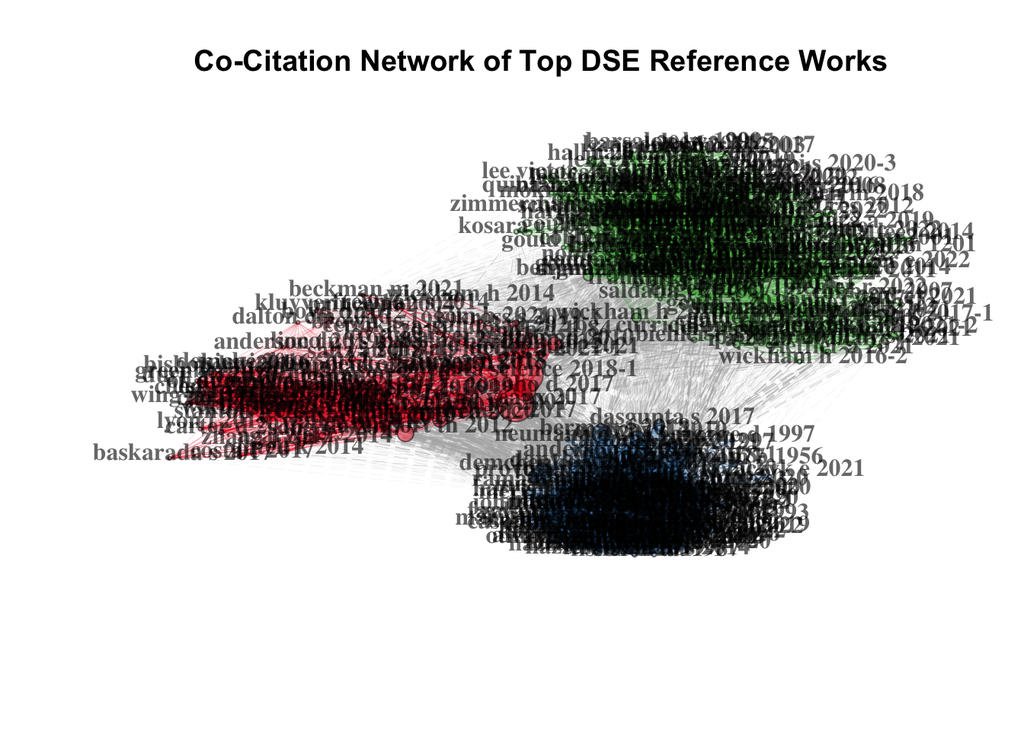

```r
inclusion.cite.count = 2
cutoff = as.integer(count(refWorks %>%
                            filter(freqCit>inclusion.cite.count)))

refNet=networkPlot(refMatrix, n=cutoff,
                   Title = "Co-Citation Network of Top DSE Reference Works",
                   size.cex=TRUE, size=10, remove.multiple=FALSE,
                   remove.isolates = TRUE, labelsize=0, edgesize = 5,
                   edges.min=0, type = "fruchterman", cluster = "leiden",
                   community.repulsion = .04)
```

```r
# we created shortnames for all duplicates, but refNet will
# only create shortnames for items that are cited at least the
# inclusion.cite.count number of times. Let's update to that.
refWorks <- refShortNames(refWorks,inclusion.cite.count)
coreDSEworks <- coreShortNames(coreDSEworks,refWorks)

# also export a pajek file from the network that I can use to generate a nicer visualization for the paper
net2Pajek(refNet,"data/refNet")
```

**Note**

**STOP HERE AND CHECK!** The clustering and layout algorithms used for this analysis have stochastic elements. *Occasionally*, when you run this, things will shake out such that the colors and clusters I reference in the text in a “hard coded” way below are mixed up. This doc is written with the assumption that you got the likely result, where the cluster with the largest nodes is red, and the cluster that is spatially the most uniform is blue. You may want to double check and see if this is your arrangement. If not, congratulations! You have obtained a rare network arrangement. If you’d like, take an extra moment to confirm that even with this less likely result, the general nature and constitution of the clusters are the same (though their outputs may be swapped from what is expected in Sections 4.1, 4.2, and 4.3 below). Then, for readability, re-running the chunk above to obtain the more frequent assignment of clusters and then re-running the dependencies below will fix things so the text matches the output.

It is important to note that the network layout and clustering algorithms used in this work include stochastic elements, and your results may vary when re-running the code or examining the interactive Quarto doc. For example, the position of certain nodes in the network may change, and the centrality measures and cluster memberships of certain works at the boundaries between literatures also change. However, the emergence of these clusters and their thematic foci is highly robust to different configurations and runs of the code. My analysis below takes steps to reduce uncertainty by separating broker works from core cluster membership, and by focusing on general trends rather than relying on specific papers whenever possible when making claims about the nature and constitution of clusters.

The network visualization, as well as computational cluster analysis of the network structure, reveal three distinct and relatively isolated clusters of co-cited literature. As I will describe in more detail in Section 4, these clusters broadly represent to collections of research focused on Undergraduate Data Science programs (red); K-12 Education (blue); and Computing for Non-Majors (green). Consistent with research on bibliometric citation network analysis (e.g., Aria & Cuccurullo, 2017; Trujillo & Long, 2018; Zupic & Čater, 2015), I conceptualize of these three clusters as representing distinct intellectual communities that together form the foundations of the data science education field. Below, I first briefly review shared or “broker” works that span these distinct communities. Then, I examine each distinct community of literature in more detail with a focus on the audiences, conceptual content, pedagogies, and methodologies that are emphasized by each.

## 3.2 Broker Works: Papers Cited by the Data Science Education Field at Large

The top ten broker works as identified by betweenness centrality are featured in Table 5. This collection includes well-known articles that work to define the nature of data science as a field (Berman et al., 2018; Cleveland, 2001; Donoho, 2017), and that present frameworks and guidelines to ensure that new data science training programs support the development of key data skills students should learn (P. Anderson et al., 2014; De Veaux et al., 2017; National Academies of Sciences, Engineering, and Medicine, 2018), including how they intersect with industry (Demchenko et al., 2016) and academia (Irizarry, 2020).

```r
# select the most "between" reference works. Show the top ten
# and include the top 50
refBrokers <- refNet[["cluster_res"]] %>%
  arrange(desc(btw_centrality)) %>%
  head(50)

# use shortnames to identify the full citation for each
# reference broker work from the refWorks data frame
refBrokers$vertex <- paste0(
  word(refBrokers$vertex,1), " ",
  str_sub(word(refBrokers$vertex,2),1,1), " ",
  word(refBrokers$vertex,3))

# refNet is shortnaming most popular with -1; fix for the join
refBrokers$vertex <- sub("(\\d{4})-1","\\1",refBrokers$vertex)

##### TODO: what is going on with dalton c 2016? shortnames seem to match fine

relevantRefs <- refWorks %>%
  filter(shortname %in% refBrokers$vertex) %>%
  filter(freqCit > inclusion.cite.count) %>%
  arrange(desc(freqCit))

datatable(left_join(refBrokers, relevantRefs, by=c("vertex"="shortname") )[c(11,12,8,10)],
  rownames=FALSE,
  colnames=c('First Author','Year','Cited Reference', '# Citing DSE Works'),
  options=list(pageLength=10, class='compact stripe')
)
```

| First Author | Year | Cited Reference | # Citing DSE Works |
| --- | --- | --- | --- |
| DATA S | 2018 | DATA SCIENCE FOR UNDERGRADUATES OPPORTUNITIES AND OPTIONS 2018 | 40 |
| DE V | 2017 | DE VEAUX RD AGARWAL M AVERETT M BAUMER BS BRAY A BRESSOUD TC BRYANT L CHENG LZ FRANCIS A GOULD R KIM AY KRETCHMAR M LU Q MOSKOL A NOLAN D PELAYO R RALEIGH S SETHI RJ SONDJAJA M TIRUVILUAMALA N ET AL C… | 45 |
| BERMAN F | 2018 | BERMAN F RUTENBAR R HAILPERN B CHRISTENSEN H DAVIDSON S ESTRIN D FRANKLIN M MARTONOSI M RAGHAVAN P STODDEN V SZALAY AS REALIZING THE POTENTIAL OF DATA SCIENCE COMMUNICATIONS OF THE ACM 61 4 PP 67-72 2… | 15 |
| DASGUPTA S | 2017 | DASGUPTA S HILL BM SCRATCH COMMUNITY BLOCKS SUPPORTING CHILDREN AS DATA SCIENTISTS CHI17 PROCEEDINGS OF THE 2017 CHI CONFERENCE ON HUMAN FACTORS IN COMPUTING SYSTEMS PP 3620-3631 2017 | 6 |
| DONOHO D | 2017 | DONOHO D 50 YEARS OF DATA SCIENCE JOURNAL OF COMPUTATIONAL AND GRAPHICAL STATISTICS 26 4 PP 745-766 2017 | 22 |
| CLEVELAND W | 2001 | CLEVELAND WS DATA SCIENCE AN ACTION PLAN FOR EXPANDING THE TECHNICAL AREAS OF THE FIELD OF STATISTICS INTERNATIONAL STATISTICAL REVIEW 69 1 PP 21-26 2001 | 16 |
| DEMCHENKO Y | 2016 | DEMCHENKO Y BELLOUM A LOS W WIKTORSKI T MANIERI A BROCKS H BECKER J HEUTELBECK D HEMMJE M BREWER S EDISON DATA SCIENCE FRAMEWORK A FOUNDATION FOR BUILDING DATA SCIENCE PROFESSION FOR RESEARCH AND INDU… | 14 |
| ANDERSON P | 2014 | ANDERSON P BOWRING J MCCAULEY R POTHERING G STARR C AN UNDERGRADUATE DEGREE IN DATA SCIENCE CURRICULUM AND A DECADE OF IMPLEMENTATION EXPERIENCE PROCEEDINGS OF THE 45TH ACM TECHNICAL SYMPOSIUM ON COMP… | 26 |
| IRIZARRY R | 2020 | IRIZARRY RA THE ROLE OF ACADEMIA IN DATA SCIENCE EDUCATION HARVARD DATA SCIENCE REVIEW 2 1 2020 | 10 |
| PROVOST F | 2013 | PROVOST F FAWCETT T DATA SCIENCE AND ITS RELATIONSHIP TO BIG DATA AND DATA-DRIVEN DECISION MAKING BIG DATA 1 1 PP 51-59 2013 | 14 |

[output cut: 41 more lines]

There are straightforward reasons that most of these works would appear in a wide variety of papers focused on data science education. They seek to define what constitutes the field, identify the skills needed to successfully participate and contribute, and describe early efforts to establish and share emerging professional programs of study. They also reflect the interdisciplinarity of the field as a whole: This short list describes work that has appeared in venues including national and international reports, major journals in the fields of statistics, major journals and proceedings in computer science, and emerging data-science-specific publications.

As is usually the case in document co-citation, broker works also tend to be the more highly cited works. This makes sense – the more a work is cited, the more visible it is and the more opportunities there are for it to appear alongside new and different references. However, some references stand out for their high betweenness centrality despite relatively modest citation counts. These include papers focused on sociological studies of data science as a field (boyd & Crawford, 2012), and one focused on precollegiate data science education. Dasgupta and Hill (Dasgupta & Hill, 2017) describes the design of a set of new blocks for the Scratch block-based programming language for children. It is also the only paper that appears within the top 20 broker papers to focus squarely on K-12 learners (another, Finzer, 2013, highlights a corresponding need to prepare K-12 teachers).

When looking at an expanded collection of the top 50 broker works, a number of other similarities emerge. A variety of popular books highlighting the ethical challenges of data science (e.g., Benjamin, 2019; D’Ignazio & Klein, 2020; Noble, 2018; O’Neil, 2016), curricular frameworks and reviews of research in related areas (Bargagliotti, 2020; Hardin et al., 2015; Lee et al., 2021), and foundational works chronicling the ascendance of computing and big data (Nolan & Temple Lang, 2010; Tukey, 1992; Wing, 2006) are included. Together, this all suggests that despite the new and at times nebulous character of data science education, there is some awareness (if not convergence) around approaches to program design, frameworks defining the key skills involved, ethical considerations, and historical foundations.

# 4. Characterizing the Three Foundational Literatures of Data Science Education

While an exploration of broker works suggests there is some shared literature that holds the field of data science education together, even the most popular of these broker works are cited by only 40 or 45 papers out of the 287 within the `coreDSEworks` dataset. This represents about 15% of the full collection of data science education core works. While the works identified above do appear to be commonly cited alongside a wide variety of other papers, this somewhat low level of overlap suggests there is still not much evidence of a common, core literature base among data science education scholarship. Consider that, in contrast, a recent bibliometric review of research on computational thinking [a similarly interdisciplinary and relatively new educational domain; Irawan et al. (2024)] in mathematics learning found that the top two reference works—Wing (2006) and Papert (1980)—were cited by 80% and 63%, respectively, of the full collection of papers analyzed.

Here, I work to better understand the distinctive characteristics of each cluster of literature in terms of its audience, content focus, pedagogical orientations, and methodologies. I focus only on references within each cluster that fall below the 80<sup>th</sup> percentile of betweenness centrality. I refer to these filtered clusters as “cluster isolates,” to emphasize that members with higher betweenness centrality have been removed. By filtering the dataset in this way, I focus only on the research papers that are unique to each cluster, that is, they are only cited alongside other reference works that are members of the same cluster. This also lessens the risk of drawing incorrect interpretations of clusters due to the uncertainty built into algorithms that determine and visualize cluster membership of bridging works.

```r
y <- refNet[["cluster_res"]]$btw_centrality
y[y==0] <- NA

# set the cutoff to lowest 80th percentile in terms of betweenness centrality
btw_cutoff <- quantile(y,c(.8),na.rm=TRUE)

referenceClusterAuthors <- refNet[["cluster_res"]] %>%
  # restrict this to only authors of papers that are not very connected
  # outside of their specific cluster
  #filter( btw_centrality < mean(refNet[["cluster_res"]]$btw_centrality) ) %>%
  filter( btw_centrality < btw_cutoff ) %>%
  group_by(cluster) %>%
  summarize(authors = list(
    paste(
      word(vertex,1),  # first word (last name)
      str_sub(word(vertex,2),1,1),     # second word (first initial)
      word(vertex,3) )
    )
  )

getClusterHub <- function(i) {
  clusterLookup <- referenceClusterAuthors$authors[[i]]
  return( refWorks %>%
    filter( !is.na( shortname ) ) %>%
    filter( shortname %in% clusterLookup ) %>%
    filter( freqCit > 2 ) %>%
    arrange( desc(freqCit) ) )
}

# add $refInfo as quick lookup for what cluster the refs belong to
for( i in 1:nrow(coreDSEworks) ) {
  coreDSEworks$refInfo[i] <- refNet[["cluster_res"]] %>%
       filter( str_detect(vertex, coreDSEworks$shortnameRefs[i]) == TRUE ) %>%
    select(cluster)
}

getHeavyCitingWorks <- function(coreDSEworks,n,range="[1-3]") {
  # filter to look at works citing at least 5 DSE refWorks
  coreCitingWorks <- coreDSEworks %>%
    filter( str_count(coreDSEworks$refInfo,range) > 5 )

  # then only include those that have >80% reWorks from cluster n
  coreCitingWorks <- coreCitingWorks %>%
    filter( str_count(coreCitingWorks$refInfo,as.character(n))
            /str_count(coreCitingWorks$refInfo,range) > .8 )

  # filter out older than 5 years
  coreCitingWorks <- coreCitingWorks %>%
    filter( coreCitingWorks$PY > 2019 )

  return( coreCitingWorks )
}
```

## 4.1 Data Science Undergraduate Major Programs

```r
datatable(getClusterHub(1)[c(6,7,3,5)],
  rownames=FALSE,
  colnames=c('First Author','Year','Cited Reference', '# Citing DSE Works'),
  options=list(pageLength=10, class='compact stripe')
)
```

| First Author | Year | Cited Reference | # Citing DSE Works |
| --- | --- | --- | --- |
| SONG I | 2016 | SONG I-Y ZHU Y BIG DATA AND DATA SCIENCE WHAT SHOULD WE TEACH EXPERT SYSTEMS 33 4 PP 364-373 2016 | 18 |
| DHAR V | 2013 | DHAR V DATA SCIENCE AND PREDICTION COMMUNICATIONS OF THE ACM 56 12 PP 64-73 2013 | 15 |
| MANYIKA J | 2011 | MANYIKA J CHUI M BROWN B BUGHIN J DOBBS R ROXBURGH C HUNG BYERS A BIG DATA THE NEXT FRONTIER FOR INNOVATION COMPETITION AND PRODUCTIVITY MCKINSEY GLOBAL INSTITUTE 2011 | 15 |
| CARVER R | 2016 | CARVER R EVERSON M GABROSEK J HORTON N LOCK R MOCKO M ROSSMAN A ROSWELL G VELLEMAN P WITMER J WOOD B GUIDELINES FOR ASSESSMENT AND INSTRUCTION IN STATISTICS EDUCATION GAISE COLLEGE REPORT 2016 2016 | 8 |
| SHAH C | 2021 | SHAH C ANDERSON T HAGEN L ET AL AN ISCHOOL APPROACH TO DATA SCIENCE HUMAN-CENTERED SOCIALLY RESPONSIBLE AND CONTEXT DRIVENJ JOURNAL OF THE ASSOCIATION FOR INFORMATION SCIENCE AND TECHNOLOGY 72 6 PP 79… | 8 |
| KLUYVER T | 2016 | KLUYVER T RAGAN-KELLEY B PEREZ F GRANGER B BUSSONNIER M FREDERIC J KELLEY K HAMRICK J GROUT J CORLAY S ET AL JUPYTER NOTEBOOKS—A PUBLISHING FORMAT FOR REPRODUCIBLE COMPUTATIONAL WORKFLOWS POSITIONING … | 7 |
| KNUTH D | 1984 | KNUTH D E LITERATE PROGRAMMING THE COMPUTER JOURNAL 27 2 PP 97-111 1984 | 7 |
| MILES M | 2014 | MILES MB HUBERMAN AM SALDANA J QUALITATIVE DATA ANALYSIS A METHODS SOURCEBOOK 2014 | 6 |
| ORTIZ-REPISO V | 2018 | ORTIZ-REPISO V GREENBERG J CALZADA-PRADO J A CROSS-INSTITUTIONAL ANALYSIS OF DATA-RELATED CURRICULA IN INFORMATION SCIENCE PROGRAMMES A FOCUSED LOOK AT THE ISCHOOLS JOURNAL OF INFORMATION SCIENCE 44 6… | 6 |
| WANG L | 2018 | WANG L TWINNING DATA SCIENCE WITH INFORMATION SCIENCE IN SCHOOLS OF LIBRARY AND INFORMATION SCIENCE JOURNAL OF DOCUMENTATION 74 6 PP 1243-1257 2018 | 6 |

[output cut: 34 more lines]

### 4.1.1 Key Characteristics of Reference Works

While there is no clear publication venue that is dominant within this collection of papers, this cluster suggests there is already quite a bit of interdisciplinary collaboration between the set of disciplines involved in the training of undergraduate data science majors. The cluster features journals and conferences focused on statistics education (the *Journal of Statistics and Data Science Education*, *Teaching Statistics*), computer science and engineering (*Communications of the ACM; Journal of Engineering Education*), information technologies (*Education and Information Technologies, Data Technologies and Applications*), and library science (*Journal of Academic Librarianship, Journal of Education for Library and Information Sciences*).

This cluster isolate of works focuses on data science teaching, curriculum, and assessment at the college level. It includes papers that describe desired skills and competencies (e.g. social responsibility and ethics, data science applications, transparent and reproducible methods, data science in industry), as well as the various roles that different departments might play in the establishment and administration of data science major programs of study. This cluster also includes reference to some of the most prominent tools used in professional and scientific data science practice, including Jupyter notebooks, R packages such as ggplot, and related reproducible programming practices.

Some items in this cluster isolate lend insight into this community’s pedagogical orientations and methodological approaches to data science education. Multiple papers refer to active learning and lab- and practice-based learning experiences for students. Several methodological texts, not related explicitly to data science but apparently informing the empirical research emerging from this community of foundational work, reference qualitative and naturalistic research methods. (This seems especially appropriate at a time when the field is working to understand what the student and instructor experience looks like in this new domain.)

### 4.1.2 Recent Citing Works

Using the shortname identifiers, we can perform a co-citation coupling analysis to identify recent coreDSEworks that heavily cite papers from the Data Science Undergraduate Major cluster. This confirms an active community of researchers that are examining the design and enactment of data science courses and programs for undergraduates. The citing works also include more recent methodological developments for studying these undergraduate data science contexts.

```r
coreCitingWorks1 <- getHeavyCitingWorks(coreDSEworks,1)

datatable(coreCitingWorks1[c(93,5,94)],
  rownames=FALSE,
  colnames=c('First Author','Year','Citing Paper'),
  options=list(pageLength=5, class='compact stripe')
)
```

| First Author | Year | Citing Paper |
| --- | --- | --- |
| ZAKARIA M | 2023 | ZAKARIA M DATA SCIENCE EDUCATION PROGRAMMES IN MIDDLE EASTERN INSTITUTIONS A SURVEY STUDY IFLA JOURNAL-INTERNATIONAL FEDERATION OF LIBRARY ASSOCIATIONS 49 1 2023 |
| VIRKUS S | 2020 | VIRKUS S GAROUFALLOU E DATA SCIENCE AND ITS RELATIONSHIP TO LIBRARY AND INFORMATION SCIENCE A CONTENT ANALYSIS DATA TECHNOLOGIES AND APPLICATIONS 54 5 2020 |
| HORTON N | 2021 | HORTON N HARDIN J INTEGRATING COMPUTING IN THE STATISTICS AND DATA SCIENCE CURRICULUM CREATIVE STRUCTURES NOVEL SKILLS AND HABITS AND WAYS TO TEACH COMPUTATIONAL THINKING JOURNAL OF STATISTICS AND DAT… |
| DONOGHUE T | 2021 | DONOGHUE T VOYTEK B ELLIS S TEACHING CREATIVE AND PRACTICAL DATA SCIENCE AT SCALE JOURNAL OF STATISTICS AND DATA SCIENCE EDUCATION 29 2021 |
| POOLE A | 2023 | POOLE A DATA FLOURISHING DEVELOPING HUMAN-CENTERED DATA SCIENCE THROUGH COMMUNITIES OF ETHICAL PRACTICE PROCEEDINGS OF THE ASSOCIATION FOR INFORMATION SCIENCE AND TECHNOLOGY 60 1 PP 338-352 2023 |
| FRIEDMAN A | 2024 | FRIEDMAN A BEASLEY Z USING TEXTUAL ANALYSIS TO EXAMINE STUDENT ENGAGEMENT IN ONLINE UNDERGRADUATE SCIENCE EDUCATION JOURNAL OF STATISTICS AND DATA SCIENCE EDUCATION 2024 |
| POOLE A | 2021 | POOLE A LEADING THE WAY A NEW MODEL FOR DATA SCIENCE EDUCATION PROCEEDINGS OF THE ASSOCIATION FOR INFORMATION SCIENCE AND TECHNOLOGY 58 1 PP 525-531 2021 |
| ROSENFELD A | 2023 | ROSENFELD A ELMALECH A INFORMATION SCIENCE STUDENTS BACKGROUND AND DATA SCIENCE COMPETENCIES AN EXPLORATORY STUDY JOURNAL OF EDUCATION FOR LIBRARY AND INFORMATION SCIENCE 64 4 PP 385-403 2023 |

## 4.2 K-12 Education and the Learning Sciences

A second cluster of foundational literature, represented by blue nodes in Figure 3, is comprised of a collection of work that describes the skills and competencies that younger learners and the public should develop related to data science. This cluster isolate includes studies that focus primarily on pre-college data science learning experiences in formal and informal learning environments as well as in everyday and home life, as well as on methods for developing students’ more general statistical and data literacies.

```r
datatable(getClusterHub(3)[c(6,7,3,5)],
  rownames=FALSE,
  colnames=c('First Author','Year','Cited Reference', '# Citing DSE Works'),
  options=list(pageLength=10, class='compact stripe')
)
```

| First Author | Year | Cited Reference | # Citing DSE Works |
| --- | --- | --- | --- |
| ERICKSON T | 2019 | ERICKSON T WILKERSON M FINZER W REICHSMAN F DATA MOVES TECHNOLOGY INNOVATIONS IN STATISTICS EDUCATION 12 2019 | 15 |
| RUBIN A | 2020 | RUBIN A LEARNING TO REASON WITH DATA HOW DID WE GET HERE AND WHAT DO WE KNOW JOURNAL OF THE LEARNING SCIENCES 29 1 PP 154-164 2020 | 12 |
| KAHN J | 2020 | KAHN J LEARNING AT THE INTERSECTION OF SELF AND SOCIETY THE FAMILY GEOBIOGRAPHY AS A CONTEXT FOR DATA SCIENCE EDUCATION JOURNAL OF THE LEARNING SCIENCES 29 1 PP 57-80 2020 | 10 |
| PHILIP T | 2016 | PHILIP TM OLIVARES-PASILLAS MC ROCHA J BECOMING RACIALLY LITERATE ABOUT DATA AND DATA-LITERATE ABOUT RACE DATA VISUALIZATIONS IN THE CLASSROOM AS A SITE OF RACIAL-IDEOLOGICAL MICRO-CONTESTATIONS COGNI… | 10 |
| CODAP - | 2022 | CODAP - COMMON ONLINE DATA ANALYSIS PLATFORM 2022 | 9 |
| STORNAIUOLO A | 2020 | STORNAIUOLO A AUTHORING DATA STORIES IN A MEDIA MAKERSPACE ADOLESCENTS DEVELOPING CRITICAL DATA LITERACIES JOURNAL OF THE LEARNING SCIENCES 29 1 PP 81-103 2020 | 9 |
| ENYEDY N | 2007 | ENYEDY N MUKHOPADHYAY S THEY DONT SHOW NOTHING I DIDNT KNOW EMERGENT TENSIONS BETWEEN CULTURALLY RELEVANT PEDAGOGY AND MATHEMATICS PEDAGOGY JOURNAL OF THE LEARNING SCIENCES 16 2 PP 139-174 2007 | 9 |
| LAMAR T | 2021 | LAMAR T BOALER J THE IMPORTANCE AND EMERGENCE OF K-12 DATA SCIENCE PHI DELTA KAPPAN 103 1 PP 49-53 2021 | 9 |
| MAKAR K | 2018 | MAKAR K RUBIN A LEARNING ABOUT STATISTICAL INFERENCE INTERNATIONAL HANDBOOK OF RESEARCH IN STATISTICS EDUCATION PP 261-294 2018 | 8 |
| GOULD R | 2021 | GOULD R TOWARD DATA-SCIENTIFIC THINKING TEACHING STATISTICS 43 2021 | 8 |

[output cut: 86 more lines]

### 4.2.1 Key Characteristics

Publications in this cluster isolate appear in journals focused on the cognitive and learning sciences such as the *Journal of the Learning Sciences* and *Cognition and Instruction*, as well as in statistics and mathematics education journals such as the *Journal for Statistics and Data Science Education*, *Statistics Education Research Journal*, and associated conferences. Several K-12 standards documents such as the Common Core State Standards in Mathematics (National Governors Association Center for Best Practices, Council of Chief State School Officers, 2010a), GAISE II (Bargagliotti, 2020), the International Data Science in Schools framework (IDSSP Curriculum Team, 2019), and the Next Generation Science Standards (National Governors Association Center for Best Practices, Council of Chief State School Officers, 2010b) are also featured in this cluster isolate.

While not all the works featured in this isolate focus specifically on K-12 education, the emphasis is on young learners and non-specialists and focuses on these learners’ interactions with data within various school subjects and everyday life (e.g. media literacy and personal data management). This cluster isolate also includes descriptions and reviews of popular software packages used in K-12, and what might be considered foundational (pre-“data science”) research on student thinking and learning about data, representations and visualizations of data, inference, and data/statistical literacy.

Consistent with the focus on K-12 education, this cluster often emphasizes the learning of data science or related skills as a component of other disciplines (e.g. science, mathematics, computing), or as part of what it means informed navigation of the modern workplace and world. In terms of pedagogy, there is an emphasis on interdisciplinary integration (including with the arts and social sciences) and storytelling-based approaches to data. Consistent with a grounding in the learning sciences, the cluster isolate includes references to design-based research, a methodology in which learning theory is operationalized within new educational designs with the goal of “…bringing about new forms of learning in order to study them” (Cobb et al., 2003, p. 10).

### 4.2.2 Recent Citing Works

Recent coreDSEworks that heavily cite papers from the K-12 Education and Learning Sciences cluster similarly include empirical studies of K-12 data science education tools and activities, and reviews that serve to examine how data science might be situated within the K-12 curricular landscape. It is worth noting that while these works indicated the phrase “data science education” in the keywords or abstract, the titles suggest less emphasis on technical or computational learning goals and more emphasis on students’ general comfort and facility with data via “data storytelling,” “data literacy,” and “data inquiry/exploration.”

```r
coreCitingWorks3 <- getHeavyCitingWorks(coreDSEworks,3)

datatable(coreCitingWorks3[c(93,5,94)],
  rownames=FALSE,
  colnames=c('First Author','Year','Citing Paper'),
  options=list(pageLength=5, class='compact stripe')
)
```

| First Author | Year | Citing Paper |
| --- | --- | --- |
| LEE V | 2022 | LEE V PIMENTEL D BHARGAVA R DIGNAZIO C TAKING DATA FEMINISM TO SCHOOL A SYNTHESIS AND REVIEW OF PRE-COLLEGIATE DATA SCIENCE EDUCATION PROJECTS BRITISH JOURNAL OF EDUCATIONAL TECHNOLOGY 53 5 2022 |
| HEDGES S | 2022 | HEDGES S GIVEN K ADDRESSING CONFIRMATION BIAS IN MIDDLE SCHOOL DATA SCIENCE EDUCATION FOUNDATIONS OF DATA SCIENCE 2022 |
| LEE V | 2021 | LEE V WILKERSON M LANOUETTE K A CALL FOR A HUMANISTIC STANCE TOWARD K-12 DATA SCIENCE EDUCATION EDUCATIONAL RESEARCHER 2021 |
| KAHN J | 2022 | KAHN J PERALTA L RUBEL L LIM V JIANG S HERBEL-EISENMANN B NOTICE WONDER FEEL ACT AND REIMAGINE AS A PATH TOWARD SOCIAL JUSTICE IN DATA SCIENCE EDUCATION EDUCATIONAL TECHNOLOGY &amp; SOCIETY 25 4 2022 |
| KAHN J | 2020 | KAHN J LEARNING AT THE INTERSECTION OF SELF AND SOCIETY THE FAMILY GEOBIOGRAPHY AS A CONTEXT FOR DATA SCIENCE EDUCATION JOURNAL OF THE LEARNING SCIENCES 29 1 2020 |
| JIANG S | 2020 | JIANG S KAHN J DATA WRANGLING PRACTICES AND COLLABORATIVE INTERACTIONS WITH AGGREGATED DATA INTERNATIONAL JOURNAL OF COMPUTER-SUPPORTED COLLABORATIVE LEARNING 15 3 2020 |
| DELANEY V | 2024 | DELANEY V LEE V HIGH SCHOOL TEACHERS DATA SET AESTHETICS INFORMATION AND LEARNING SCIENCES 125 7/8 2024 |
| LAMAR T | 2021 | LAMAR T BOALER J THE IMPORTANCE AND EMERGENCE OF K-12 DATA SCIENCE PHI DELTA KAPPAN 103 1 2021 |
| ZHAO Y | 2024 | ZHAO Y BERTLING J HODGE L DYER E BRIDGING DATA AND ART INVESTIGATING DATA-ART CONNECTIONS IN A DATA-ART INQUIRY PROGRAM JOURNAL OF SCIENCE EDUCATION AND TECHNOLOGY 2024 |
| LEE V | 2021 | LEE V DRAKE J CAIN R THAYNE J REMEMBERING WHAT PRODUCED THE DATA INDIVIDUAL AND SOCIAL RECONSTRUCTION IN THE CONTEXT OF A &lt;I&gt;QUANTIFIED SELF&lt;/I&gt; ELEMENTARY DATA AND STATISTICS UNIT COGNITI… |

[output cut: 19 more lines]

## 4.3 Computational Approaches to Data for Non-Majors

A third cluster consists of work, represented by green nodes in Figure 3, that describes bringing the computational tools and methods of data science to students who are non-specialists. Structurally, this cluster features fewer nodes with high betweenness measures or high citation counts as compared to the other two clusters. Members of the Computational Approaches for Data for Non-Majors cluster isolate (Table 10) emphasize computational methods including data mining, simulation, and computing enacted in science contexts.

```r
datatable(getClusterHub(2)[c(6,7,3,5)],
  rownames=FALSE,
  colnames=c('First Author','Year','Cited Reference', '# Citing DSE Works'),
  options=list(pageLength=10, class='compact stripe')
)
```

| First Author | Year | Cited Reference | # Citing DSE Works |
| --- | --- | --- | --- |
| HAVILL J | 2019 | HAVILL J EMBRACING THE LIBERAL ARTS IN AN INTERDISCIPLINARY DATA ANALYTICS PROGRAM PROCEEDINGS OF THE 50TH ACM TECHNICAL SYMPOSIUM ON COMPUTER SCIENCE EDUCATION PP 9-14 2019 | 7 |
| KHURI S | 2017 | KHURI S VANHOVEN M KHURI N INCREASING THE CAPACITY OF STEM WORKFORCE MINOR IN BIOINFORMATICS PROCEEDINGS OF THE 2017 ACM SIGCSE TECHNICAL SYMPOSIUM ON COMPUTER SCIENCE EDUCATION PP 315-320 2017 | 6 |
| TARTARO A | 2015 | TARTARO A CHOSED RJ COMPUTER SCIENTISTS AT THE BIOLOGY LAB BENCH PROCEEDINGS OF THE 46TH ACM TECHNICAL SYMPOSIUM ON COMPUTER SCIENCE EDUCATION PP 120-125 2015 | 5 |
| BRYANT C | 2019 | BRYANT C CHEN Y CHEN Z GILMOUR J GUMIDYALA S HERCE-HAGIWARA B KOURES A LEE S MSEKELA J PHAM A T A MIDDLE-SCHOOL CAMP EMPHASIZING DATA SCIENCE AND COMPUTING FOR SOCIAL GOOD PROCEEDINGS OF THE 50TH ACM … | 5 |
| PLAUE C | 2015 | PLAUE C COOK LR DATA JOURNALISM LESSONS LEARNED WHILE DESIGNING AN INTERDISCIPLINARY SERVICE COURSE PROCEEDINGS OF THE 46TH ACM TECHNICAL SYMPOSIUM ON COMPUTER SCIENCE EDUCATION SIGCSE 15 PP 126-131 2… | 5 |
| SHEARER C | 2000 | SHEARER C THE CRISP-DM MODEL THE NEW BLUEPRINT FOR DATA MINING JOURNAL OF DATA WAREHOUSING 5 4 PP 13-22 2000 | 4 |
| GOODFELLOW I | 2016 | GOODFELLOW I BENGIO Y COURVILLE A BENGIO Y DEEP LEARNING 1 2016 | 4 |
| DRYER A | 2018 | DRYER A WALIA N CHATTOPADHYAY A A MIDDLE-SCHOOL MODULE FOR INTRODUCING DATA-MINING BIG-DATA ETHICS AND PRIVACY USING RAPID-MINER AND A HOLLYWOOD THEME PROCEEDINGS OF THE 49TH ACM TECHNICAL SYMPOSIUM O… | 4 |
| HAQQI S | 2018 | HAQQI S SOORIAMURTHI R MACDONALD B BEGANDY C CAMERON J PIROLLO B BECKER E CHOFFO J DAVIS C FARRELL M DATA JAM INTRODUCING HIGH SCHOOL STUDENTS TO DATA SCIENCE PROCEEDINGS OF THE 23RD ANNUAL ACM CONFER… | 4 |
| HEY T | 2009 | HEY T TANSLEY S TOLLE K GRAY J THE FOURTH PARADIGM DATA-INTENSIVE SCIENTIFIC DISCOVERY 2009 | 4 |

[output cut: 15 more lines]

### 4.3.1 Key Characteristics

Unlike the more multidisciplinary foundations of the other clusters, the third cluster is founded more squarely within the computational sciences. Publications in this cluster isolate primarily appear in Computer Science (the *ACM’s Special Interest Group in Human-Computer Interaction*; ) and Computing Education (the *ACM’s Special Interest Group in Computer Science Education “SIG-CSE”*; *Koli Calling*; the *ACM’s International Conference on Computing “ICER”*) conferences and associated publications.

The papers in this cluster isolate address multiple student audiences, including undergraduate and pre-collegiate (including both middle and high school) populations. However, it is distinguished conceptually from both of the other clusters in different ways. Whereas the first cluster includes work that is squarely focused on undergraduate major programs, this cluster emphasizes the role of data for undergraduate non-major programs of study at institutions of higher learning, including minor and certificate programs and other STEM majors. This may reflect a community that investigates data science education within specific application domains; for example, data science experiences and frameworks in the context of biology, health, and industry are represented here. The papers in this cluster isolate that focus on K-12 emphasize curricular development of new, computationally-rich experiences for youth, rather than curricula that integrate data into existing subject matter or studies that theorize or empirically study student reasoning with data.

Like the other clusters, this cluster isolate includes some historical (pre-“data science”) references that shed light on pedagogy and methodology. There is a reference to project-based learning, and to references to self-determination theory and expectancy-value theory which posit the personal, social, and external factors that motivate students to learn. These theoretical foundations in individual motivation depart slightly from the other two clusters’ orientations toward team-based and active learning methods, which are founded in socioconstructivist theories to learning.

One historical reference worth explaining for readers who are less familiar with computing-forward is a reference to the “Iris dataset,” which was first published in the *Annals of Eugenics*. The dataset is included by default in both R and Python scikit-learn, and is used to teach machine learning—affirming this cluster’s emphasis on computational techniques. However the venue, if nothing else, invites reflection on when and how to introduce students to the “difficult past of statistics” (Kennedy-Shaffer, 2024) and ongoing ethical dimensions of data science.

### 4.3.2 Citing Works

```r
coreCitingWorks2 <- getHeavyCitingWorks(coreDSEworks,2)

datatable(coreCitingWorks2[c(93,5,94)],
  rownames=FALSE,
  colnames=c('First Author','Year','Citing Paper'),
  options=list(pageLength=5, class='compact stripe')
)
```

| First Author | Year | Citing Paper |
| --- | --- | --- |
| MIKE K | 2020 | MIKE K DATA SCIENCE EDUCATION CURRICULUM AND PEDAGOGY PROCEEDINGS OF THE 2020 ACM CONFERENCE ON INTERNATIONAL COMPUTING EDUCATION RESEARCH ICER 2020 2020 |
| MIKE K | 2021 | MIKE K HARTAL G HAZZAN O WIDENING THE SHRINKING PIPELINE THE CASE OF DATA SCIENCE PROCEEDINGS OF THE 2021 IEEE GLOBAL ENGINEERING EDUCATION CONFERENCE EDUCON 2021 |
| HAZZAN O | 2021 | HAZZAN O MIKE K A JOURNAL FOR INTERDISCIPLINARY DATA SCIENCE EDUCATION COMMUNICATIONS OF THE ACM 64 8 2021 |
| HAZZAN O | 2023 | HAZZAN O MIKE K GUIDE TO TEACHING DATA SCIENCE AN INTERDISCIPLINARY APPROACH GUIDE TO TEACHING DATA SCIENCE AN INTERDISCIPLINARY APPROACH PP 1-321 2023 |
| MIKE K | 2022 | MIKE K HAZZAN O MACHINE LEARNING FOR NON-MAJOR DATA SCIENCE STUDENTS A WHITE BOX APPROACH STATISTICS EDUCATION RESEARCH JOURNAL 21 2 2022 |
| MIKE K | 2020 | MIKE K NEMIROVSKY-ROTMAN S HAZZAN O INTERDISCIPLINARY EDUCATION - THE CASE OF BIOMEDICAL SIGNAL PROCESSING IEEE GLOBAL ENGINEERING EDUCATION CONFERENCE EDUCON 2020-APRIL PP 339-343 2020 |
| MIKE K | 2020 | MIKE K HAZAN T HAZZAN O EQUALIZING DATA SCIENCE CURRICULUM FOR COMPUTER SCIENCE PUPILS ACM INTERNATIONAL CONFERENCE PROCEEDING SERIES 2020 |

## 4.4 Works that Cite Across Communities

Finally, I searched the coreDSEworks dataset for examples of records whose reference lists feature a balance of references across all three of the clusters identified above (including broker works). However, this proved difficult for multiple reasons. Only approximately 15 of the 288 coreDSEworks included *any* references from each of the three clusters identified in this analysis.

```r
bridges <- coreDSEworks %>%
  filter( str_count(coreDSEworks$refInfo,"[1-3]") > 3 )

bridges <- bridges %>%
  filter( str_count(bridges$refInfo,as.character("1")) > 0 )

bridges <- bridges %>%
  filter( str_count(bridges$refInfo,as.character("2")) > 0 )

bridges <- bridges %>%
  filter( str_count(bridges$refInfo,as.character("3")) > 0 )

bridges <- bridges %>% filter(PY > 2019)

datatable(bridges[c(93,5,94)],
  rownames=FALSE,
  colnames=c('First Author','Year','Citing Paper'),
  options=list(class='compact stripe')
)
```

| First Author | Year | Citing Paper |
| --- | --- | --- |
| MIKE K | 2020 | MIKE K DATA SCIENCE EDUCATION CURRICULUM AND PEDAGOGY PROCEEDINGS OF THE 2020 ACM CONFERENCE ON INTERNATIONAL COMPUTING EDUCATION RESEARCH ICER 2020 2020 |
| WRIGHT C | 2024 | WRIGHT C MENG Q BRESHOCK M ATTA L TAUB M JAGER L MUSCHELLI J HICKS S OPEN CASE STUDIES STATISTICS AND DATA SCIENCE EDUCATION THROUGH REAL-WORLD APPLICATIONS JOURNAL OF STATISTICS AND DATA SCIENCE EDUC… |
| HSU Y | 2024 | HSU Y MAPPING THE LANDSCAPE OF DATA SCIENCE EDUCATION IN HIGHER GENERAL EDUCATION IN TAIWAN A COMPREHENSIVE SYLLABI ANALYSIS EDUCATION SCIENCES 14 7 2024 |
| MAKSIMENKOVA O | 2020 | MAKSIMENKOVA O NEZNANOV A RADCHENKO I COLLABORATIVE LEARNING IN DATA SCIENCE EDUCATION A DATA EXPEDITION AS A FORMATIVE ASSESSMENT TOOL CHALLENGES OF THE DIGITAL TRANSFORMATION IN EDUCATION ICL2018 VO… |
| WILKERSON M | 2020 | WILKERSON M POLMAN J SITUATING DATA SCIENCE EXPLORING HOW RELATIONSHIPS TO DATA SHAPE LEARNING JOURNAL OF THE LEARNING SCIENCES 29 1 2020 |
| LI Y | 2023 | LI Y WANG Y LEE Y CHEN H PETRI A CHA T TEACHING DATA SCIENCE THROUGH STORYTELLING IMPROVING UNDERGRADUATE DATA LITERACY THINKING SKILLS AND CREATIVITY 48 2023 |
| JEON I | 2024 | JEON I KIM S KANG S DEVELOPING STANDARDS FOR EDUCATIONAL DATASETS BY SCHOOL LEVEL A FRAMEWORK FOR SUSTAINABLE K-12 EDUCATION SUSTAINABILITY 16 12 2024 |
| ISRAEL-FISHELSON R | 2023 | ISRAEL-FISHELSON R MOON P TABAK R WEINTROP D PREPARING STUDENTS TO MEET THEIR DATA AN EVALUATION OF K-12 DATA SCIENCE TOOLS BEHAVIOUR &amp; INFORMATION TECHNOLOGY 2023 |
| DONOGHUE T | 2021 | DONOGHUE T VOYTEK B ELLIS S TEACHING CREATIVE AND PRACTICAL DATA SCIENCE AT SCALE JOURNAL OF STATISTICS AND DATA SCIENCE EDUCATION 29 2021 |
| VANCE E | 2021 | VANCE E USING TEAM-BASED LEARNING TO TEACH DATA SCIENCE JOURNAL OF STATISTICS AND DATA SCIENCE EDUCATION 29 3 2021 |

[output cut: 16 more lines]

```r
bridges <- coreDSEworks %>%
  filter( str_count(coreDSEworks$refInfo,"[1-3]") > 5 )

bridges <- bridges %>%
  filter( str_count(bridges$refInfo,as.character("1"))
          /str_count(bridges$refInfo,"[1-3]") > .1 )

bridges <- bridges %>%
  filter( str_count(bridges$refInfo,as.character("2"))
          /str_count(bridges$refInfo,"[1-3]") > .1 )

bridges <- bridges %>%
  filter( str_count(bridges$refInfo,as.character("3"))
          /str_count(bridges$refInfo,"[1-3]") > .1 )

bridges <- bridges %>% filter(PY > 2019)

datatable(bridges[c(93,5,94)],
  rownames=FALSE,
  colnames=c('First Author','Year','Citing Paper'),
  options=list(class='compact stripe')
)
```

| First Author | Year | Citing Paper |
| --- | --- | --- |
| WRIGHT C | 2024 | WRIGHT C MENG Q BRESHOCK M ATTA L TAUB M JAGER L MUSCHELLI J HICKS S OPEN CASE STUDIES STATISTICS AND DATA SCIENCE EDUCATION THROUGH REAL-WORLD APPLICATIONS JOURNAL OF STATISTICS AND DATA SCIENCE EDUC… |
| WILKERSON M | 2020 | WILKERSON M POLMAN J SITUATING DATA SCIENCE EXPLORING HOW RELATIONSHIPS TO DATA SHAPE LEARNING JOURNAL OF THE LEARNING SCIENCES 29 1 2020 |
| LI Y | 2023 | LI Y WANG Y LEE Y CHEN H PETRI A CHA T TEACHING DATA SCIENCE THROUGH STORYTELLING IMPROVING UNDERGRADUATE DATA LITERACY THINKING SKILLS AND CREATIVITY 48 2023 |
| ISRAEL-FISHELSON R | 2023 | ISRAEL-FISHELSON R MOON P TABAK R WEINTROP D PREPARING STUDENTS TO MEET THEIR DATA AN EVALUATION OF K-12 DATA SCIENCE TOOLS BEHAVIOUR &amp; INFORMATION TECHNOLOGY 2023 |
| VANCE E | 2021 | VANCE E USING TEAM-BASED LEARNING TO TEACH DATA SCIENCE JOURNAL OF STATISTICS AND DATA SCIENCE EDUCATION 29 3 2021 |
| MOON P | 2023 | MOON P ISRAEL-FISHELSON R TABAK R WEINTROP D THE TOOLS BEING USED TO INTRODUCE YOUTH TO DATA SCIENCE PROCEEDINGS OF IDC 2023 - 22ND ANNUAL ACM INTERACTION DESIGN AND CHILDREN CONFERENCE REDISCOVERING … |
| LEE H | 2022 | LEE H MOJICA G THRASHER E BAUMGARTNER P INVESTIGATING DATA LIKE A DATA SCIENTIST KEY PRACTICES AND PROCESSES STATISTICS EDUCATION RESEARCH JOURNAL 21 2 2022 |
| PODWORNY S | 2022 | PODWORNY S HÜSING S SCHULTE C A PLACE FOR A DATA SCIENCE INTRODUCTION IN SCHOOL BETWEEN STATISTICS AND PROGRAMMING STATISTICS EDUCATION RESEARCH JOURNAL 21 2 2022 |

As might be expected, the works that do appear as citing across clusters tend to be review papers surveying the field. However, even these review papers tend to emphasize work from only one cluster, with passing references to others. Given the sensitivity of this set of findings to small perturbations, I advise caution in drawing strong inferences from this list.

# 5. Toward a More Coherent Data Science Education

This analysis started with an intentionally narrow set of core works—papers that explicitly identify “data science education” in their titles, keywords, or abstracts. While these works certainly do not represent all the literature that one might associate with the study of data science education as it has developed over the past decade, it undoubtedly serves as a window into what the field is and where it might be going.

Consistent with the ambitious and interdisciplinary nature of data science itself, this core collection of “data science education” works are constructed atop a sprawling landscape of other disciplines and communities. By mapping this landscape, this paper sought to identify the “intellectual structure” of the field—the shared understandings, key resources, and lines of specialization through which it is characterized. An analysis of the co-citation patterns of reference works suggested that while there are some commonly co-cited papers that indicate general agreement about the nature, purpose, and importance of data science education, this field does not yet have a shared core literature. Instead, there seem to be three distinct and active research communities that draw on substantially different foundational literatures focused on Data Science as an Undergraduate Major, K-12 Education and the Learning Sciences, and Computational Approaches to Data for Non-Majors, respectively.

## 5.1 Evidence of Fragmentation

These findings confirm what many in our community already suspect: the emerging field of data science education *is* relatively fragmented, and we are all still working to find one another. However, when looking broadly at co-citation patterns of the data science education literature, some of the specific divisions that have been identified across *subcommunities*—for example, between how statistics and computing approach data science (Carmichael & Marron, 2018; Cetinkaya-Rundel, Posner, et al., 2019; Cetinkaya-Rundel, Danyluk, et al., 2019; Msweli et al., 2023), or between different approaches to K-12 data science education (Rosenberg & Jones, 2024)—do not (yet) reflect deep or persistent fractures in the intellectual foundations of the communities. This is encouraging. While there are certainly distinctions between approaches to data science pedagogy, communities with similar audiences and goals appear to be in conversation, drawing from shared bodies of work even if they are not necessarily at a point of building consensus.

Instead, there are starker divisions between larger communities that appear to be organized around a complex combination of audience (e.g. specialists vs non-specialists) and content emphasis (e.g. statistics, data literacy, and machine learning methods). In some ways, these divisions are sensible in that they reflect differences in student audiences, disciplinary orientations, and intended outcomes. Publication venue also seems to play an important role, both in terms of scholarly field, and format. However, these distinctions between audience and content emphasis do not entirely explain the intellectual structure that is emerging. For example, both the K-12 Education and the Computing Approaches to Data for Non-Majors clusters feature several works that describe curriculum or programs for K-12 students, but these papers are rarely co-cited with similar works from the other cluster. Similarly, there are overlaps in different clusters’ disciplinary orientations and emphases. Works exploring computer science specific approaches or topics within data science education appear in both the Data Science Undergraduate Major Programs and Computational Approaches to Data for Non-Majors clusters, and common pedagogies (project- based, student-centered, and domain integrative approaches) are emphasized in all three clusters though with different core references.

This fragmentation across student audience and educational level, with at times overlapping but isolated efforts within different clusters, raises concerns about the field’s attention to building a coherent research basis. For example, the Introduction to Data Science/Mobilize project appears in both the K-12 Education/Learning Sciences and Computational Approaches to Data for Non-Majors clusters isolates, via different references [Gould et al. (2016) and Gould (2018); respectively]. This suggests there are citational ruptures across clusters regarding otherwise very conceptually coherent research topics. Fragmentation of literature across student audiences also raises concerns about our ability to work together to build conceptually coherent data science learning trajectories, as also noted by Rosenberg and Jones (2024). Closer collaboration (or at least, leveraging a common literature base) between communities is likely needed to ensure K-12 students are adequately prepared for future learning. The field would benefit from clearer communication about what general data science competencies as might be needed for particular domain applications reflected in the Computational Approaches to Data, and what is the more specific preparation that is required for Data Science Undergraduate Major programs. And educational efforts across all communities would benefit from deeper understanding of what are main topic areas, audiences, methods, assessments, and learning theories leveraged within the literature as a whole.

## 5.2 Identifying Common Themes

Although these different (though somewhat interdisciplinary) communities focusing on different combinations of student populations, content learning goals, and pedagogical and methodological orientations, there are a number of resonances to highlight. Across all three clusters, although the references are to different papers, there is a shared thematic focus on active, project-based, and interdisciplinary pedagogies that teach data science in meaningful contexts. There are also clear references to integrating ethics into data science education, and issues of power, ethics, and data for social good were additionally reflected in the broker works that were often co-cited with members of multiple clusters. Though the clusters each focused on starkly different tools, they all explicitly included multiple tools as a core foundation. To relate these commonalities to the themes identified in Mike et al’s (2023) thematic cluster analysis, all three literature clusters demonstrate general convergence around Mike’s thematic clusters 2 - Pedagogy and 5 - Social aspects.

We can also understand some of the key distinctions between the clusters in terms of the themes outlined in Mike et al (2023). The most obvious of these is around the 1 - Curriculum. The Data Science for Undergraduate Majors cluster is primarily concerned with 1.1- Principles of data science curriculum design, and 1.5- Curriculum design for data science majors. The K-12 Education/Learning Sciences cluster is concerned with 1.4- Curriculum design for K-12 pupils, as is the Computational Approaches to Data for Non-Majors. All of the clusters, to some extent, include references that speak to 1.2- Approaches to data science education and 1.3- Introduction to data science. The Computational Approaches to Data for Non-Majors cluster included more specific references to various types of 4- Domain adaptation.

All three clusters demonstrate different distributions of the themes in 3-STEM Skills with the Data Science. As anticipated, the Data Science for Undergraduate Majors cluster emphasizes more statistically-oriented stills, while the Data Science for Computational Approaches to Data for Non-Majors focuses on computational skills. The deeper look at specific titles afforded by the analysis here suggests that this might be understood as a distinction around “who or what” is expected to do the work of organizing and making sense of data – humans (via data reasoning) or computers (via classification/machine learning).

## 5.3 Limitations

Any review of literature involves tradeoffs to maintain interpretable results and a manageable scope. A few important things to remember about this current analysis is that because the field is still new and relatively small, the patterns identified here are particularly sensitive to perturbations. Given that most researchers publish repeatedly, and each of these works impact the construction of the co-citation network at the center of this analysis, some of the patterns are likely driven by only one or a few researchers or research groups. For example, the constitution of cluster 3 is likely disproportionately driven by the large co-citation list included in the book *Guide to Teaching Data Science: An Interdisciplinary Approach* (Hazzan, 2023). However, these clusters also bear face validity in that they represent what newcomers to the field are likely to find upon an initial literature search, and what they are likely to understand as relevant literature as they consult reference lists themselves.

The small size and interdisciplinarity of publications also make this analysis more sensitive than typical to errors and inconsistencies in reference format, and other “data wrangling” challenges. It is for this reason that I included more detail about data cleaning methods, which included extensively tested combinations of manual and automated reference record matching, than I typically would. Finally, as described some above, the tools used to conduct this analysis include stochastic elements that introduce some elements of uncertainty to the output. To protect against drawing inappropriate conclusions, I focused only on “cluster isolates” when examining the constituencies of each cluster, reducing the likelihood that papers that are susceptible to “boundary errors” (e.g. uncertain cluster membership assignments) were used to define distinctions between clusters.

Hausten and Larivier (2015) highlight the dangers of an over-reliance on bibliometric methods to describe disciplines or scholarly impact. This is particularly true when looking at literature across communities that have very different publication practices. Throughout this paper, I sought to emphasize the structure of the emerging data science education literature: how it reveals distinct communities, how it is distributed across different publication fora, and how it attends to different student audiences, content emphases, and thematic foci. While at times I identify specific papers to exemplify the characteristics of these structural features, the purpose of this paper is not to analyze or assess the impact of any specific authors, institutions, research agendas, or journals on the field.

## 5.4 Opening a Conversation

It was exciting and humbling to engage in this analysis and to learn more about the exciting Data Science Education work going on. It is my hope that this analysis serves as not only an exploratory map, but also as a navigational one that can help researchers interested in data science education to more intentionally reach across fields and consult broader literatures. In addition to the interactivity/searchability I have embedded into this article, I plan to maintain the dse-citan code in hopes that it can facilitate better searching and interfacing across clusters as the field continues to grow. I invite colleagues to join me (or bug me, as the need may arise).

If we do not work across divides, we risk missed opportunities for collaboration or, worse, we risk building incoherent or inequitable data science trajectories for youth. As it stands the clusters of research focused on K-12 education boast very different emphases, and are designed to serve different populations of students. Such differences in potential experiences should at least be understood and clearly communicated to students, educators, and policymakers. Similarly, at the intersection of K-12 to undergraduate study, we need to better understand what kind of preparation is needed for future majors, non-majors who may nevertheless employ data-intensive methods in their work, and for all students. Navigating the “wild west” of new, interdisciplinary research can be difficult, but as educators we owe it to students to work together to build strong, coherent, and data-rich experiences across the academic lifespan.

## 6. References

Anderson, P., Bowring, J., McCauley, R., Pothering, G., & Starr, C. (2014). *An undergraduate degree in data science: Curriculum and a decade of implementation experience*. 145150. https://doi.org/10.1145/2538862.2538936

Anderson, T., & Parker, N. (2019). Keeping the human in the data scientist: Shaping human-centered data science education. *Proceedings of the Association for Information Science and Technology*, *56*, 601–603. https://doi.org/10.1002/pra2.103

Aria, M., & Cuccurullo, C. (2017). Bibliometrix: An r-tool for comprehensive science mapping analysis. *Journal of Informetrics*, *11*(4), 959–975. https://doi.org/10.1016/j.joi.2017.08.007

Bargagliotti, A. (2020). *Pre-K-12 guidelines for assessment and instruction in statistics education II (GAISE II)* (Second edition). American Statistical Association.

Baumer, B. S., & Horton, N. J. (2023). Data Science Transfer Pathways From Associate’s to Bachelor’s Programs. *Harvard Data Science Review*, *5*(1). https://doi.org/10.1162/99608f92.e2720e81

Benjamin, R. (2019). *Race after technology: Abolitionist tools for the new jim code* (1st edition). Polity.

Ben-Zvi, D., Makar, K., & Garfield, J. (Eds.). (2018). *International handbook of research in statistics education*. Springer International Publishing. https://doi.org/10.1007/978-3-319-66195-7

Berman, F., Rutenbar, R., Hailpern, B., Christensen, H., Davidson, S., Estrin, D., Franklin, M., Martonosi, M., Raghavan, P., Stodden, V., & Szalay, A. S. (2018). Realizing the potential of data science. *Commun. ACM*, *61*(4), 6772. https://doi.org/10.1145/3188721

Biehler, R., Frischemeir, D., Reading, C., & Shaughnessy, J. M. (2018). *Reasoning About Data*. Springer. https://rune.une.edu.au/web/handle/1959.11/22757

Boaler, J., Conrad, B., Ford, B., Mazzeo, R., & Nelson, J. (2024). Three Views on the California Math Framework. *Notices of the American Mathematical Society*, *71*(06), 1. https://doi.org/10.1090/noti2957

boyd, danah, & Crawford, K. (2012). Critical questions for big data. *Information, Communication & Society*, *15*(5), 662–679. https://doi.org/10.1080/1369118X.2012.678878

Carmichael, I., & Marron, J. S. (2018). Data science vs. statistics: two cultures? *Japanese Journal of Statistics and Data Science*, *1*(1), 117–138. https://doi.org/10.1007/s42081-018-0009-3

Cetinkaya-Rundel, M., Danyluk, A., Forbes, J., & Posner, M. (2019). Building Bridges for Data Science Education. *Proceedings of the 50th ACM Technical Symposium on Computer Science Education*, 1249. https://doi.org/10.1145/3287324.3293745

Cetinkaya-Rundel, M., Posner, M., Forbes, J., & Danyluk, A. (2019). *Building bridges for data science education*. https://ww2.amstat.org/meetings/jsm/2019/onlineprogram/AbstractDetails.cfm?abstractid=300267

Cleveland, W. S. (2001). Data Science: an Action Plan for Expanding the Technical Areas of the Field of Statistics. *International Statistical Review*, *69*(1), 21–26. https://doi.org/10.1111/j.1751-5823.2001.tb00477.x

Cobb, P., Confrey, J., diSessa, A., Lehrer, R., & Schauble, L. (2003). Design Experiments in Educational Research. *Educational Researcher*, *32*(1), 9–13. https://doi.org/10.3102/0013189X032001009

D’Ignazio, C., & Klein, L. F. (2020). *Data feminism*. The MIT Press.

Dasgupta, S., & Hill, B. M. (2017). *Scratch community blocks: Supporting children as data scientists*. 36203631. https://doi.org/10.1145/3025453.3025847

*Data Science Education*. (n.d.). https://hdsr.mitpress.mit.edu/data-science-education

De Veaux, R. D., Agarwal, M., Averett, M., Baumer, B. S., Bray, A., Bressoud, T. C., Bryant, L., Cheng, L. Z., Francis, A., Gould, R., Kim, A. Y., Kretchmar, M., Lu, Q., Moskol, A., Nolan, D., Pelayo, R., Raleigh, S., Sethi, R. J., Sondjaja, M., … Ye, P. (2017). Curriculum Guidelines for Undergraduate Programs in Data Science. *Annual Review of Statistics and Its Application*, *4*(1), 15–30. https://doi.org/10.1146/annurev-statistics-060116-053930

Demchenko, Y., Belloum, A., Los, W., Wiktorski, T., Manieri, A., Brocks, H., Becker, J., Heutelbeck, D., Hemmje, M., & Brewer, S. (2016). *IEEE 8th international conference on cloud computing technology and science*. 620–626. https://doi.org/10.1109/CloudCom.2016.0107

Donoho, D. (2017). 50 years of data science. *Journal of Computational and Graphical Statistics*, *26*(4), 745766. https://doi.org/10.1080/10618600.2017.1384734

*DT: A wrapper of the javascript library ’DataTables’*. (2024). https://CRAN.R-project.org/package=DT

Edelson, D. C., & Gordin, D. (1998). Visualization for learners: A framework for adapting scientists’ tools. *Computers & Geosciences*, *24*(7), 607–616. https://doi.org/10.1016/S0098-3004(98)00363-X

Fincher, S. A., & Robins, A. V. (Eds.). (2019). *The cambridge handbook of computing education research* (1st ed.). Cambridge University Press. https://doi.org/10.1017/9781108654555

Finzer, W. (2013). The Data Science Education Dilemma. *Technology Innovations in Statistics Education*, *7*(2). https://doi.org/10.5070/T572013891

Fruchterman, T. M. J., & Reingold, E. M. (1991). Graph drawing by force-directed placement. *Software: Practice and Experience*, *21*(11), 1129–1164. https://doi.org/10.1002/spe.4380211102

Gould, R. (2018). *MOBILIZE: A DATA SCIENCE CURRICULUM FOR 16-YEAR-OLD STUDENTS*.

Gould, R., Machado, S., Ong, C., Johnson, T., Molyneux, J., Nolen, S., Tangmunarunkit, H., Trusela, L., & Zanontian, L. (2016, December 30). *Promoting Understanding of Statistics about Society*. https://doi.org/10.52041/SRAP.16402

Hardin, J., Hoerl, R., Horton, N. J., Nolan, D., Baumer, B., Hall-Holt, O., Murrell, P., Peng, R., Roback, P., Lang, D. T., & Ward, M. D. (2015). Data science in statistics curricula: Preparing students to "think with data". *The American Statistician*, *69*(4), 343–353. https://www.jstor.org/stable/24592136

Haustein, S., & Larivière, V. (2015). *The Use of Bibliometrics for Assessing Research: Possibilities, Limitations and Adverse Effects* (I. M. Welpe, J. Wollersheim, S. Ringelhan, & M. Osterloh, Eds.; pp. 121–139). Springer International Publishing. https://doi.org/10.1007/978-3-319-09785-5_8

Hazzan, O. (2023). *Guide to Teaching Data Science: An Interdisciplinary Approach* (1st ed). Springer International Publishing AG.

Hazzan, O., & Mike, K. (2021). A journal for interdisciplinary data science education. *Blog@CACM*, *64*(8), 1011. https://doi.org/10.1145/3469281

Held, M. (2022). Know thy tools! Limits of popular algorithms used for topic reconstruction. *Quantitative Science Studies*, *3*(4), 1054–1078. https://doi.org/10.1162/qss_a_00217

Hudson, R. A., Mojica, G. F., Lee, H. S., & Casey, S. (2024). Data moves as a focusing lens for learning to teach with CODAP. *Computers in the Schools*, *0*(0), 1–26. https://doi.org/10.1080/07380569.2024.2411705

IDSSP Curriculum Team. (2019). *Curriculum frameworks for introductory data science*. The International Data Science in Schools Project.

Irawan, E., Rosjanuardi, R., & Prabawanto, S. (2024). Research trends of computational thinking in mathematics learning: A bibliometric analysis from 2009 to 2023. *Eurasia Journal of Mathematics, Science and Technology Education*, *20*(3), em2417. https://doi.org/10.29333/ejmste/14343

Irizarry, R. A. (2020). The Role of Academia in Data Science Education. *Harvard Data Science Review*, *2*(1). https://doi.org/10.1162/99608f92.dd363929

Kennedy-Shaffer, L. (2024). Teaching the difficult past of statistics to improve the future. *Journal of Statistics and Data Science Education*, *32*(1), 108–119. https://doi.org/10.1080/26939169.2023.2224407

Kirst, M., & Venezia, A. (2017). *Disconnect by design: College readiness efforts still hampered by divided k12 and higher education systems* (2nd ed.). Routledge.

Lee, V. R., Wilkerson, M. H., & Lanouette, K. (2021). A call for a humanistic stance toward K12 data science education. *Educational Researcher*, *50*(9), 664–672. https://doi.org/10.3102/0013189X211048810

Mike, K., Kimelfeld, B., & Hazzan, O. (2023). The Birth of a New Discipline: Data Science Education. *Harvard Data Science Review*, *5*(4). https://doi.org/10.1162/99608f92.280afe66

Msweli, N. T. M., Mawela, T., & Twinomurinzi, H. T. (2023). Data Science Education A Scoping Review. *Journal of Information Technology Education: Research*, *22*, 263–294. https://www.informingscience.org/Publications/5173

National Academies of Sciences, Engineering, and Medicine. (2018). *Data Science for Undergraduates: Opportunities and Options*. National Academies Press.

National Academies of Sciences, Engineering, and Medicine. (2023). *Foundations of Data Science for Students in Grades K-12: Proceedings of a Workshop*. The National Academies Press. https://doi.org/10.17226/26852

National Governors Association Center for Best Practices, Council of Chief State School Officers. (2010b). *Common core state standards - mathematics*.

National Governors Association Center for Best Practices, Council of Chief State School Officers. (2010a). *Common core state standards - mathematics*.

Noble, S. U. (2018). *Algorithms of oppression: How search engines reinforce racism*. NYU Press. https://nyupress.org/9781479837243/algorithms-of-oppression

Nolan, D., & Temple Lang, D. (2010). Computing in the statistics curricula. *The American Statistician*, *64*(2), 97107. https://doi.org/10.1198/tast.2010.09132

O’Neil, C. (2016). *Weapons of math destruction: How big data increases inequality and threatens democracy* (1st edition). Crown.

Pangrazio, L., & Selwyn, N. (2019). ‘Personal data literacies’: A critical literacies approach to enhancing understandings of personal digital data. *New Media & Society*, *21*(2), 419–437. https://doi.org/10.1177/1461444818799523

Papert, S. (1980). *Mindstorms: Children, computers, and powerful ideas*. Basic Books, Inc.

Rosenberg, J., & Jones, R. S. (2024). Data Science Learning in Grades K12: Synthesizing Research Across Divides. *Harvard Data Science Review*. https://doi.org/10.1162/99608f92.b1233596

Shah, C., Anderson, T., Hagen, L., & Zhang, Y. (2021). An iSchool approach to data science: Human-centered, socially responsible, and context-driven. *Journal of the Association for Information Science and Technology*, *72*(6), 793–796. https://doi.org/10.1002/asi.24444

Šubelj, L., Van Eck, N. J., & Waltman, L. (2016). Clustering Scientific Publications Based on Citation Relations: A Systematic Comparison of Different Methods. *PLOS ONE*, *11*(4), e0154404. https://doi.org/10.1371/journal.pone.0154404

Traag, V. A., Waltman, L., & Eck, N. J. van. (2019). From Louvain to Leiden: guaranteeing well-connected communities. *Scientific Reports*, *9*(1), 5233. https://doi.org/10.1038/s41598-019-41695-z

Trujillo, C. M., & Long, T. M. (2018). Document co-citation analysis to enhance transdisciplinary research. *Science Advances*, *4*(1), e1701130. https://doi.org/10.1126/sciadv.1701130

Tukey, J. W. (1992). *The Future of Data Analysis* (S. Kotz & N. L. Johnson, Eds.; pp. 408–452). Springer. https://doi.org/10.1007/978-1-4612-4380-9_31

Weiland, T., & Engledowl, C. (2022). Transforming Curriculum and Building Capacity in K12 Data Science Education. *Harvard Data Science Review*, *4*(4). https://doi.org/10.1162/99608f92.7fea779a

Wickham, H., François, R., Henry, L., Müller, K., & Vaughan, D. (2023). *Dplyr: A grammar of data manipulation*.

Wing, J. M. (2006). Computational thinking. *Commun. ACM*, *49*(3), 3335. https://doi.org/10.1145/1118178.1118215

Zupic, I., & Čater, T. (2015). Bibliometric Methods in Management and Organization. *Organizational Research Methods*, *18*(3), 429–472. https://doi.org/10.1177/1094428114562629